# 智能制造系统设计 · 第 6 讲：企业信息系统（一）ERP、MES、PLM

刘训臣

山东科技大学 机械电子工程学院

# 第〇部分 · 课程介绍与本讲定位

- 四个内容块主线：**系统全景 → ERP → MES → PLM 与集成**
- 本讲解决一个问题：企业里八套信息系统**各管什么、数据怎样互相喂**
- 课程位置：第 6 次课（模块 4 前半）；第 7 次课接 CRM／WMS／APS 与 8D
- 课堂要求：会算 MRP、会画追溯链、会给业务场景选系统

## 本讲教学内容与主线

**内容块 1 · 制造企业系统全景**：八个系统的边界与集成关系；四条流（信息流、物料流、资金流、质量流）

**内容块 2 · ERP**：从 MRP（物料需求计划）到 ERPII 的五级演进；主生产计划、BOM 与低层码、能力需求与闭环 MRP；MRP 数量算例、六条单据链与选型实施

**内容块 3 · MES**：定位（ERP 与设备之间的执行层）、MESA（制造执行系统协会）十一项功能、三目标（防错、改善、追溯）；防错六类规则、改善闭环、追溯与 OEE（设备综合效率）算例

**内容块 4 · PLM（产品生命周期管理）与系统集成**：产品生命周期、PDM、BOM、协同开发；漏斗与甘特图；一个 ECN 在 PLM→ERP→MES 中的流转

> 一句话：**ERP 管资源、MES 管执行、PLM 管产品，靠数据与流程集成在一起。**

## 教学进度 · 10 次课全览

> 上一页讲完本讲的四个内容块；这一页把它放进十次课的全景。

| 次 | 模块 | 主题 |
| --- | --- | --- |
| 1 | 导论与 3.1 | 课程导论、工程与社会与质量工程（一）：国家战略、工程的社会属性、质量管理基础 |
| 2 | 3.1 | 质量工程（二）与质量工具：五大工具 APQP／FMEA／MSA／SPC／PPAP、CPK、QC 七大手法 |
| 3 | 3.2 | 工业工程与精益生产（＋实验 2 课时：线性规划与工业工程例子） |
| 4 | 3.3、3.4 | 安全工程与环保工程：海因里希法则、事故树 FTA、风险评估、三废治理、双碳 |
| 5 | 3.5、3.6 | 成本管理与人力资源：成本构成、投资回收期、NPV／IRR、质量成本、人才与激励 |
| **6** | **4.1～4.3** | **企业信息系统（一）：ERP、MES、PLM 与系统集成全景** |
| 7 | 4、6 | 企业信息系统（二）与 8D：CRM／WMS／APS，8D 八步与软件开发流程 |
| 8 | 工程伦理（一） | 工程事故与伦理准则：凯悦酒店、NSPE 准则、伦理决策框架 |
| 9 | 工程伦理（二） | 风险、安全与责任，工程师与组织：责任判定、组织文化与信任 |
| 10 | 伦理（三）与综合 | 技术的社会意义、国际化、AI 伦理；智能设计应用、前沿、课程设计与总复习 |

**结论：本讲是第 6 次课，前五讲给方法，后四讲转向系统与责任。**

## 本讲在课程中的位置

**前接**：第 3 次课的精益生产（八大浪费、拉动、看板）——MES 是精益在现场的数字化载体。

**本讲**：把“企业”作为一个系统来设计——八套软件各自回答什么问题、数据在哪里产生、怎样集成。

**后接**：第 7 次课的 CRM／WMS／APS 与 8D 报告——8D 的 D4（根本原因）要调用 MES 的追溯数据，D6（验证）要调用 SPC（统计过程控制）。

- 一条贯穿线：**计划 → 执行 → 反馈 → 改进**（PDCA 在企业系统里的实体化）
- 本讲的技术落点是“四流”；社会落点是“数据采集与追溯的边界”

**结论：本讲承接精益的流动思想，把企业系统做成计划、执行、反馈、改进的闭环。**

## 三个系统，三个问题

> 上一页讲课程位置；这一页用三个问题把 ERP、MES、PLM 分开。

| 系统 | 回答的问题 | 管理对象 | 时间尺度 |
| --- | --- | --- | --- |
| ERP | 资源够不够？何时下计划、何时采购 | 订单、物料、资金、产能 | 月—周 |
| MES | 计划能不能执行？做没做对 | 工单、工序、设备、质量 | 周—秒 |
| PLM | 产品怎么设计？变更怎么管 | 图纸、BOM、工艺、变更 | 年—天 |

- 三者的关系不是“谁替代谁”，而是**计划、执行、产品定义**三个层次
- 边界判据：**问资源与钱 → ERP；问做没做、做得怎样 → MES；问产品本身是什么 → PLM**
- 实际系统功能会重叠（ERP 也管生产、MES 也报成本），所以必须有**唯一的权威数据源**

**结论：三个问题对应三个层次，边界判据是问资源、问执行、问产品。**

## 本讲伦理与社会落点

> 上一页区分了三个系统；这一页先挂出本讲的两处伦理落点。
- **数据采集与员工隐私**：MES 记录“谁、何时、在哪台设备、做了什么”，颗粒度可以细到每一次扫码
- **追溯与监控的边界**：追溯的正当目的是质量闭环（找问题、防再发），不是对个人的全天候考核
- 判断准则：**目的正当、范围最小、留存有期、使用受限**（四条同时满足才算合规）
- 这两点在内容块 4 展开，并在第五部分的课堂讨论里继续

**结论：追溯要服务于质量闭环，目的、范围、留存、使用四条同时满足才算合规。**

## 推导留给 AI：课程介绍与本讲定位（汇总）

> 上一页挂了伦理落点；这一页留四道推导题收束本部分。
- ERP、MES、PLM 各自的“权威数据”是什么？分别列出它们的主数据表
- 四流中的“质量流”由哪些记录承载？与检验记录、SPC 数据如何对应
- 一个企业只有 ERP 没有 PLM，会在哪些具体环节出问题？举三个场景
- 若只能先上一个系统，应该先上哪个？用数据依赖关系论证

**结论：四道题都要落到具体表与具体字段，写不成表的回答不算过关。**

## 本讲 90 分钟怎么安排

> **六块 6＋20＋28＋24＋4＋4 ＝ 86 分钟；余 4 分钟作机动，正好 90 分钟。**

| 序 | 时间块 | 讲什么 | 分钟 |
| --- | --- | --- | --- |
| 0 | 开场与回顾 | 六问、能力、路线图 | 6 |
| 1 | 内容块 1 全景 | 八个系统边界、四流 | 20 |
| 2 | 内容块 2 ERP | MRP、MPS 与 BOM | 28 |
| 3 | 内容块 3 MES | 十一功能、三目标 | 24 |
| 4 | 内容块 4 PLM | BOM 家族、ECN | 4 |
| 5 | 讨论与小结 | 选系统例题、作业 | 4 |

- 三个主内容块 72 分钟：全景 20 建地图、ERP 28 算料、MES 24 看执行
- 时间紧先压 ERP 的模块罗列与 MES 的行业调查；**MRP 算例、追溯链、ECN 一条链**不能压
- PLM 与集成只点三条骨架（四阶段、BOM 家族、ECN），要展开就从 ERP 模块里挪 4 分钟

## 第 5 讲回顾与检查：六个问题

> **每题 30 秒：答不出的那一条，正是今天要用的那一条。**

| 问题 | 一句话答案 | 今天怎么用 |
| --- | --- | --- |
| ① 成本性态 | 固定＋变动；单位固定成本随产量下降 | 系统投资也是固定成本，要摊到每件 |
| ② 量本利 | $Q_0=F/(p-v)=200/40=5$ 万件 | 固定成本抬升，保本点跟着抬 |
| ③ 回收期 | 累计转正处插值，真题 $P_t=5.33$ 年 | 从少召回、少停机里回收 |
| ④ 净现值 | 逐年折现求和，$NPV>0$ 即可行 | 收益多是“避免损失”，先折成现金 |
| ⑤ 岗位说明书 | 七块：岗位标识、职责、权限、工作关系、绩效标准、环境、任职资格 | 上线先改岗：系统管理员、数据分析员 |
| ⑥ 经营杠杆 | $DOL=3$（7.5 万件时） | 固定成本越高，订单波动越放大 |

- 六问分三类：①②⑥ 靠算，③④ 看现金流，⑤ 靠写
- 抽查：合上讲义写答案，随机点两人各答一问；答不出不扣分，课后补
- 一句提醒：今天每套系统的账，都要用这六把尺子量

## 本讲学习目标与能力清单

> **四条能力＝四个动作：说清系统、画出数据流、做成选型、讲透集成。**

| 能力 | 具体要求 | 落点 | 验收标准（可检查） |
| --- | --- | --- | --- |
| 会说清系统 | 一句话说清边界与主责 | 内容块 1～3 | 任指场景，说出系统与理由 |
| 会画数据流 | 五段数据流，箭头写名 | 内容块 1、4 | 画出 ECN 三跳流转图 |
| 会做选型 | 产品／资源／执行三问 | 内容块 2、第五部分 | 例题 2 八场景对六个 |
| 会分析集成 | 三层次、四方式，判接口 | 内容块 1、4 | 说清字段、频率、主数据 |

- 两条靠说与画、两条靠判断；不要求背软件品牌，要求指得出、讲得清
- 验收标准写成能当场做出来的动作，不写“理解”“掌握”
- 与本章三节的学习目标对齐：ERP 的三流整合与核心组成、PLM 的生命周期各阶段、MES 的效率与成本

**结论：四条能力对应四个动作，验收只看能不能当场做出来。**

## 系统软件在智能制造中的位置

> **硬件决定能力上限，软件决定能力用出来多少；ERP、MES、PLM 各占住计划、执行、产品定义一层。**
- **决策层**：BI（商业智能），把经营指标算出来，回答“这一季赚不赚”
- **计划层**：ERP（＋APS、SCM），回答“做多少、何时买、钱够不够”
- **执行层**：MES（＋WMS、TQM），回答“做没做、做得对不对、料在哪”
- **控制层**：PLC、CNC、机械手、检测仪器，回答“这一刀怎么走、参数到不到”
- **产品定义层**：PLM 贯穿全生命周期，回答“产品到底是什么、改到第几版”
- 三句定位：ERP 是“数字化企业的**后台核心**”，MES“**桥接** ERP 与设备”，PLM 是“**唯一**面向产品创新的系统”
- 判据：**越往下越实时、越往上越综合**；接口的字段与刷新频率，比选哪个品牌更决定成败

## 考试视角：本讲真题分布

> **六卷必有一道 3 分单选（MES 目标）；五卷有一道 5 分简答（系统组成）。**

| 考点 | 题型与分值 | 出现卷次 | 备考口径 |
| --- | --- | --- | --- |
| MES 三目标 | 单选 3 分 | 六卷全有 | 防错、改善、追溯；“销售”干扰 |
| 系统组成 | 简答 5 分 | 五卷有 | 名称＋一句功能，成对作答 |
| ERP 选型 | 未单独命题 | 无 | 按三问判据作答 |
| MES 边界 | 未单独命题 | 无 | ERP 管计划，MES 管执行 |
| 四流与集成 | 未单独命题 | 无 | 作综合题、论述题素材 |

- 单选是送分题（第 7 或 8 题）：三个目标背下来，“销售”永远不选——它归 CRM／ERP
- 简答五卷有、2022A 没有：判分看**名称准确、功能不串**——APS 是排程，MES 是执行
- 五组成固定搭配：ERP、MES、PLM、APS、CRM；WMS、SCM 可替换其一

## 本讲路线图与课前准备

> **一条主线：先建地图，再算物料，再看执行，最后看变更。**

| 部分 | 入口问题 | 讲什么 | 出口 |
| --- | --- | --- | --- |
| 一 全景 20 | 企业里有几套系统 | 八个系统边界、四流 | 地图画得出 |
| 二 ERP 28 | 物料何时到、要多少 | MRP、MPS 与 BOM | 净需求算得对 |
| 三 MES 24 | 计划执行得怎样 | 十一功能、三目标 | 追溯链画得出 |
| 四 PLM 4 | 产品定义谁说了算 | BOM 家族、ECN | 变更说得清 |
| 五 例题 4 | 会不会用 | 八场景、两算例 | 选得对、算得快 |
| 六 小结 4 | 记住什么 | 知识地图、作业 | 复习有抓手 |

- 接口关系：地图（谁和谁连）→ 算料（连什么数据）→ 执行（数据怎么回）→ 变更（数据怎么改）
- 课前准备：抄一遍量本利与回收期公式；带计算器与 A4 纸；预习 4.1、4.3、4.4 的学习目标
- 想一个你见过的工厂：它上了哪几套系统？哪两套最常对不上账？开场点名用

## 产教融合 · 本讲企业真题：一张订单的旅程与系统断点

> **企业场景：**企业一批齿轮订单交期 15 天、实际延期 6 天；库存账实不符率 6.4%，图纸版本混乱造成 3 批返工、损失 12 万元。

| 企业真实问题 | 本讲工具 | 学生产出 |
| --- | --- | --- |
| 销售、计划、生产、仓储、研发各说各话，系统间数据不通 | 系统全景图、订单数据流、主数据、断点诊断矩阵 | 断点清单＋集成方案（作业 2、4） |

- **教案对应：**第四章 设计对象；**企业参与：**信息部提供系统清单、接口清单与主数据表
- **验收：**不少于 5 个断点，含证据、影响、责任部门与实施优先级。

# 第一部分 · 第 1 内容块：制造企业系统全景

- 一个订单在企业里走一圈：从询价到收款经过哪些系统
- 六个核心系统的一句话边界：ERP（企业资源计划）、MES（制造执行系统）、PLM（产品生命周期管理）、CRM（客户关系管理）、WMS（仓储管理系统）、APS（高级计划与排程）
- 四条流：信息流、物料流、资金流、质量流及其落点
- 集成的三个层次、四种集成方式，与一个前提：主数据统一

## 制造企业的四类业务：研发、计划、生产、供应

| 业务 | 回答的问题 | 关键输出 | 断链表现 |
| --- | --- | --- | --- |
| 研发 | 产品是什么、怎么做 | 图纸、BOM、工艺 | 设计与制造两张皮 |
| 计划 | 做什么、做多少、何时做 | 主计划、物料需求 | 交期靠催、库存靠猜 |
| 生产 | 做没做、做得对不对 | 工单、工序、检验 | 在制不清、追溯断链 |
| 供应 | 料在哪、何时到 | 采购单、库存、齐套 | 停线等料、呆滞并存 |

- 四类业务不是四个部门，而是一张订单必须穿过的四段。
- 研发的输出是下游的输入：BOM 与工艺决定计划算得准不准。
- BOM 是物料清单：ERP 用它算料，MES 用它领料，PLM 管它的版本。
- 计划的输出是采购与生产的起跑枪：没有冻结期的主计划等于每天重排。
- 生产的输出是交期与成本的证据：报工与检验决定回算和归集。
- 供应的输出是齐套：齐套率不足时，排程再优也会被缺料打断。
- 判据：四类业务是否共用一套物料号、一张 BOM、一个交期口径。

## 企业信息系统的五层：从设备到协同

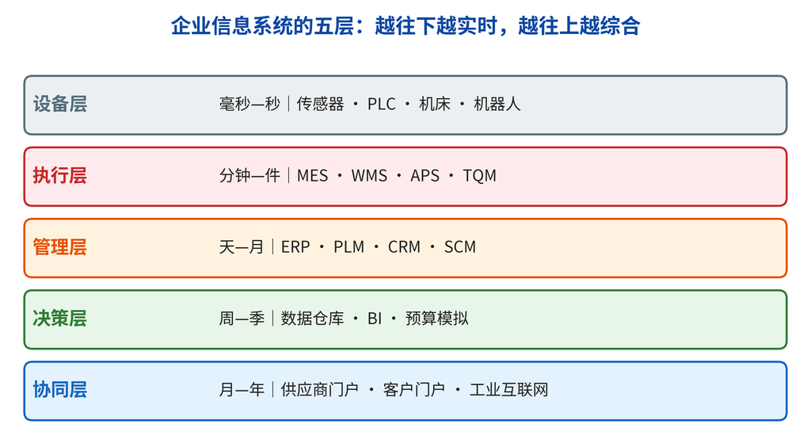

- **是什么**：设备→执行→管理→决策→协同，五层是“计划—执行—控制”向两端延伸的结果
- **为什么**：每层回答的问题不同（动不动／做没做／够不够／赚不赚／和谁协同），混层就必然越权
- **怎么判断**：看时间尺度（毫秒—年）与数据性质：决策层只消费汇总指标，不产生交易数据

## 八个系统的分工：管什么，也要说清不管什么

| 系统 | 管什么 | 不管什么 | 常见误用 |
| --- | --- | --- | --- |
| ERP | 订单、物料、资金 | 工序执行与设备 | 工单当派工单 |
| MES | 工单、工序、质量 | 总账、采购、税务 | 报表当财务账 |
| PLM | 图纸、BOM、变更 | 库存数量与在制 | 当文件网盘 |
| CRM | 客户、商机、报价 | 生产进度与物料 | 当订单系统 |
| WMS | 库位、批次、盘点 | 成本核算与排程 | 库存当财务账 |
| APS | 有限产能的顺序 | 执行记录与实际 | 当排程报表 |

- **一句话边界**：ERP 算账、MES 管执行、PLM 管产品定义、CRM 管客户、WMS 管库位、APS 管顺序。
- 外圈两个：SRM（供应商关系管理）管采购协同，SCADA（数据采集与监视控制）管设备采集，都不替代 ERP 的采购订单与应付、MES 的工单与追溯。
- 边界判据：谁产生、谁负责；其余系统只读，不复制。
- 一个系统“能做什么”看功能，“该做什么”看它在数据链上的位置。
- 选型先问“它不管什么”，比问“它能做什么”更能避免功能重叠。
- 判据：八个系统能否用一张表说清主责数据与下游消费者。

## 系统全景：先读箭头，再读方块

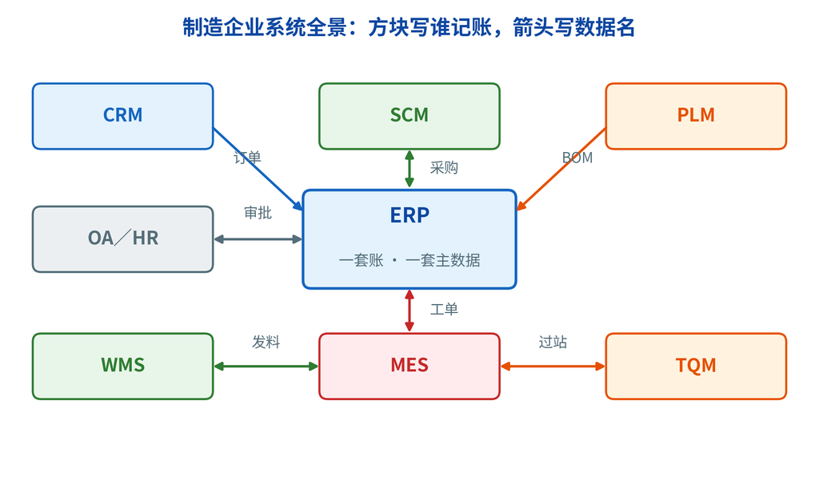

- **是什么**：八套系统围着一个 ERP 转，方块是“谁记账”，箭头是“谁给谁数据”
- **为什么**：接口清单就是照着箭头列的——先有数据流，才谈得上系统边界
- **怎么判断**：任取一条箭头，说得出数据名、频率、主责系统，才算读懂这张图
- 三条主箭头：PLM→ERP（图纸与 MBOM，即制造物料清单）、ERP→MES（工单与计划）、MES→ERP（产量、消耗、质量）

## 四流：信息流、物料流、资金流、质量流

> 上一页看系统之间的箭头；这一页换一个视角，讲穿过所有系统的四条流。

| 流 | 载体 | 产生环节 | 典型数据 |
| --- | --- | --- | --- |
| 信息流 | 单据与记录 | 全流程 | 订单、工单、工艺参数、报表 |
| 物料流 | 实物与批次 | 采购→仓储→生产→发货 | 批次号、库位、在制品、成品 |
| 资金流 | 凭证与账目 | 采购付款、生产归集、销售收款 | 应付、成本、应收、现金流 |
| 质量流 | 检验与追溯记录 | 来料、过程、成品、售后 | 检验值、不良代码、SPC（统计过程控制）、投诉 |

- 前三条流是传统 ERP 的三流（物料流、资金流、信息流）；**质量流是智能制造新增的第四流**
- 四流在系统中以“异构张量”的方式挂到同一组节点（设备、工单、批次）上，才能统一决策
- 判据：一个系统若只记录“结果”不记录“过程”，它就管不住质量流

## 四流在各系统里的落点

| 系统 | 主责流 | 典型数据 | 粒度 | 谁读它 |
| --- | --- | --- | --- | --- |
| ERP | 资金流＋信息流 | 订单、库存金额、成本 | 月／周 | 财务、计划 |
| MES | 质量流＋信息流 | 工单进度、参数、不良 | 秒／件 | 车间、质量 |
| PLM | 信息流（产品定义） | 图纸、BOM、工艺、ECN（工程变更单） | 版本 | 研发、工艺 |
| WMS | 物料流 | 收发货、库位、批次 | 托盘／件 | 仓储、采购 |
| CRM | 信息流（客户） | 商机、订单、服务请求 | 次 | 销售、市场 |
| APS | 信息流（计划） | 排程、负荷、交期 | 班次／工序 | 计划、车间 |

- 同一条流会被多个系统读写，但**只有一个系统是“写”的主责**，其余是“读”

**结论：四流都要有唯一的写主责；主责不清，同一事件永远有多种评判。**

## 订单的五段旅程：每一步交什么数据

1. **订单评审**（CRM＋ERP）：需求、信用、价格 → 销售订单与交期承诺。
2. **主计划**（ERP）：订单、预测、库存 → 主生产计划，MRP（物料需求计划）展开出采购申请。
3. **齐套采购**（ERP＋SRM＋WMS）：采购申请、供应商交期 → 采购订单与到货批次。
4. **排程**（APS）：工单、工艺、设备日历 → 工序级开工与完工时点。
5. **执行与交付**（MES＋WMS＋ERP）：报工、检验、入库、发货 → 追溯记录与发票。
- 五段之间交接的不是文件，而是**单据＋状态＋责任人**三件套。
- 交期链条：采购 15 天＋制造 18 天＋物流 3 天＝36 天，承诺 42 天，缓冲 6 天。
- 任何一段进度不回写，下一段只能按计划假设排，计划必然越排越假。
- 判据：任取一个订单号，10 分钟内拉出五段的状态与责任人。

## 数据一致性：同一件事，只能有一种口径

| 口径要素 | 常见分歧 | 统一做法 | 验证 |
| --- | --- | --- | --- |
| 对象 | 物料、批次、序列号三套标识 | 主数据定唯一键 | 三系统同键查询 |
| 时点 | 承诺日、完工日、开票日 | 指标注明统计时点 | 月末对账 |
| 范围 | 是否含在检、冻结、退货 | 写清分子分母 | 抽样复算 |
| 算法 | 及时率按单还是按行 | 指标字典固化公式 | 双人独立计算 |

- 示例：某月 200 张订单，销售口径 184 张及时（92%），生产 170 张（85%），财务 156 张（78%）。
- 差异不在数据，在定义：承诺日、完工日、开票日，含不含尾数与退货。
- 跨系统不追求强一致：财务凭证要强一致，车间状态可最终一致。
- 对账四要素：对什么键、在什么时点、差异阈值多少、差异由谁处理。
- 一致性是设计出来的：先定指标字典，再建接口，最后才做报表。
- 判据：同一指标在两套系统里能否复算出同一个数。

## 集成的三个层次

> 上一页判完数据口径；这一页把集成按由浅到深的三个层次拆开。
1. **数据集成**：接口传数据（点对点 → 集成总线／平台），解决“看得到”
2. **流程集成**：跨系统的业务流串起来（订单→工单→发料→入库→结算），解决“走得通”
3. **决策集成**：同一套指标与口径支撑决策（交期承诺、成本核算），解决“算得准”
- 三个层次的门槛依次升高：数据集成靠 IT（信息技术），流程集成靠管理，决策集成靠**统一的指标体系**
- 判断一个企业集成到什么水平，最直接的办法是问：**一张报表能不能跨三个系统自动生成**

## 主数据治理：七类对象、一套编码、一个归口

| 主数据 | 编码／结构规则 | 主责系统 | 失控后果 |
| --- | --- | --- | --- |
| 物料 | 一物一码，属性分离 | ERP | 一物多码、账实不符 |
| 客户 | 信用代码＋内部号 | CRM／ERP | 重复客户、信用失控 |
| 供应商 | 资质＋账户双校验 | SRM／ERP | 重复付款、质量风险 |
| BOM | 版本＋生效日期 | PLM | 错料、返工、召回 |
| 工艺路线 | 工序＋工位＋工时 | PLM 工艺 | 排程失真、成本偏差 |

- 编码用无含义数字码＋属性字段，别把部门、年份、图号塞进编码。
- 治理四步：申请—审批—发布—冻结；变更走 ECN，不许先改后补。
- BOM 与工艺路线必须带版本和生效日期，否则接口传的是哪一版说不清。
- 主数据 Owner 在业务部门，不在 IT；IT 只负责规则与工具。
- 物料码由 PLM 提出、ERP 发布；发布后全网只读。
- 引用方只读不写：PLM、MES、WMS 用 ERP 的物料码，不另建一套。
- 判据：同一物料在三处的编码、描述、单位完全一致。
- 另两类：设备与工位（MES 主责）、组织与人员（人力资源主责），同规则、同归口。

## 接口怎么建：四种方式与一个判据

| 集成方式 | 机制 | 适用场景 | 主要风险 |
| --- | --- | --- | --- |
| 点对点接口 | 两系统直连 | 系统少、变动小 | 数量平方增长、难维护 |
| 中间表／文件 | 定时批量交换 | 日结、报表类 | 时延大、易重复或丢失 |
| 消息队列／总线 | 事件驱动、异步 | 实时、多系统联动 | 建设与运维成本高 |
| API（应用程序接口）／集成平台 | 统一网关与治理 | 云端、多组织 | 治理与安全要求高 |

- 两类数据分开建：**主数据**用订阅同步（变更即广播），**事务数据**用事件驱动（发生即推送）
- 契约五要素（字段、触发、时点、幂等、对账）要写进接口文档，否则联调必吵架
- 判据：接口异常时，能否在 1 小时内定位到字段、时点与责任人

## 点对点与集成平台：算一笔接口数量的账

| 系统数 n | 点对点接口 | 平台端点 2n | 差值（点对点−平台） |
| --- | --- | --- | --- |
| 3 | 3 | 6 | −3 |
| 4 | 6 | 8 | −2 |
| 5 | 10 | 10 | 0 |
| 6 | 15 | 12 | ＋3 |
| 8 | 28 | 16 | ＋12 |
| 10 | 45 | 20 | ＋25 |

- 公式：$N_{p2p}=n(n-1)/2$，$N_{hub}=2n$（每条连接两端各一个适配器端点）。
- 5 套系统是分水岭：再往上，平台在接口数量上开始占优。
- 平台真正省的不是条数，而是**变更半径**：换一套系统只改一个适配器。
- 但平台有建设费与运维费，3 到 4 套系统时点对点通常更便宜。
- 点对点不是落后，是低系统数下的理性选择；平台也不是默认答案。
- 判据：接口年变更次数 × 影响系统数 > 平台年成本，才值得上平台。
- 平台建设费是固定成本，接口越多、变更越频，越容易摊薄。

## 信息孤岛：烟囱系统是怎么长出来的

| 成因 | 现场表现 | 造成的孤岛 | 破解抓手 |
| --- | --- | --- | --- |
| 部门预算制 | 各部门自购系统 | 数据在部门内闭环 | 立项审数据接口 |
| 按功能立项 | 只解单点，不管上下游 | 同一对象多套编码 | 企业级架构评审 |
| 考核指标分割 | 各部门各算各账 | 口径冲突、互相甩锅 | 统一指标字典 |
| 供应商锁定 | 接口私有、升级受制 | 换系统等于重建 | 合同写数据可导出 |
| 历史包袱 | 老系统没人敢动 | 新旧并行、双份录入 | 设退役时间表 |

- 三类孤岛：技术孤岛连不上、数据孤岛对不上、业务孤岛不愿连。
- 烟囱系统的经济学：单独立项快、当年预算好过，集成成本推到以后。
- 最贵的不是重复建设，是同一件事重复录入、同一指标重复解释。
- 破局顺序：先定主数据与指标，再谈接口与平台。
- 否则平台只是把孤岛连成“群岛”，看着连通，仍然各自为政。
- 判据：新系统立项报告有没有写“与谁交换什么数据、何时、谁负责”。
- 组织边界在哪里，数据边界往往就在哪里。

## 系统实施失败的五个原因与三个止损点

| 原因 | 早期征兆 | 代价 | 干预窗口 |
| --- | --- | --- | --- |
| 目标错位 | 上线指标是模块数 | 上线即闲置 | 立项时 |
| 主数据脏 | 一物多码、BOM 对不上 | 联调无限期 | 蓝图前 |
| 流程照搬 | 手工例外原样搬进系统 | 系统背锅、回 Excel | 蓝图期 |
| 治理失效 | 跨部门争议无人拍板 | 范围蔓延、延期 | 每周例会 |
| 运营断档 | 关键用户回原岗 | 数据逐渐失真 | 上线前 3 个月 |

- 五个原因里，选错软件通常不是主因，前三个都是管理欠账。
- 失败不是上线失败，而是上线半年后没人用、数据不可信。
- 三个止损点：蓝图评审、主数据切换、上线后第一次月结。
- 一期功能少而闭环，比一期功能全而半成品更容易成功。
- 判据：项目周报能否同时回答范围、进度、数据、风险四件事。
- 反直觉：最该砍的是“顺便一起上”的模块，不是最难的模块。
- 启动前先问：业务 Owner 是谁，能不能为跨部门口径拍板。

## 选型四步：需求、评分、试点、合同

| 阶段 | 交付物 | 关键动作 | 否决项 |
| --- | --- | --- | --- |
| 需求 | 需求清单 | 访谈一线，量化痛点 | 只有愿望没有指标 |
| 评分 | 加权评分表 | 权重先定，再打分 | 权重事后调整 |
| 试点 | POC（概念验证）方案 | 用最难场景试 | 只演示标准流程 |
| 合同 | 验收清单与退出条款 | 接口、数据、SLA（服务级别协议）写清 | 接口范围留白 |

- 需求分三级：Must 不满足即淘汰，Should 计分，Could 加分。
- 加权评分：$S=\sum_i w_i s_i$，$\sum_i w_i=1$；权重必须在打分前锁定。
- 算例（满分 5）：功能、集成、成本、服务、技术权重 0.30／0.25／0.20／0.15／0.10；A 各项 4／3／5／4／3 得 3.85，B 各项 3／4／4／3／4 得 3.55。
- 合同四条款：验收标准、接口清单、数据归属与导出、未达标退出。
- 试点选最难的场景，标准流程谁都能演示。
- 判据：供应商能否在 POC 中用你的真实数据跑通一个闭环。

## ERP 与 MES：为什么不能互相替代

| 维度 | ERP | MES | 混用的后果 |
| --- | --- | --- | --- |
| 时间粒度 | 月、周、日 | 班次、分钟、秒 | 计划粗、执行盲 |
| 管理对象 | 订单、物料、资金 | 工单、工序、批次 | 成本清、过程糊 |
| 数据性质 | 结果与汇总 | 过程与事件 | 无法追溯与防错 |
| 核算方式 | 标准成本、差异 | 实际工时、消耗 | 成本失真 |
| 变更节奏 | 月结、版本受控 | 实时重排、异常处置 | 一边冻结、一边乱变 |

- ERP 工单是承诺，MES 工单是任务；一个回答“要多少”，一个回答“谁怎么做”。
- ERP 记结果，MES 记过程；追溯靠过程，核算靠结果。
- ERP 加生产模块仍难替代 MES：设备连接、秒级采集、工序在制，不在其目标里。
- MES 也不能替代 ERP：总账、采购、税务、资金不在其范围内。
- 判据：同一工单状态不一致时，先看谁产生，再定谁为准。
- 进度看 MES，金额看 ERP，这是两条不能混的账。

## MES 与 APS：一个负责排，一个负责做

| 维度 | APS | MES | 衔接点 |
| --- | --- | --- | --- |
| 核心问题 | 先做哪个、何时做 | 做了没有、做得怎样 | 工序级计划 |
| 约束来源 | 设备、工装、人员、物料 | 现场异常、实际节拍 | 产能与状态回写 |
| 时间尺度 | 周—班次，滚动重排 | 班次—秒，实时调度 | 冻结期与重排触发 |
| 输出 | 工序开工与完工时点 | 报工、检验、追溯 | 工单工序状态 |
| 假设 | 模型化产能与良率 | 实际发生的偏差 | 偏差回流修正模型 |

- APS 解组合优化：有限产能下最小化拖期，典型目标 $\min\sum_i w_iT_i$，$T_i=\max(0,C_i-d_i)$。
- MES 解执行与异常：设备故障、缺料、质量异常时，先保证现场不停、数据不丢。
- 没有 MES 的实绩回写，APS 的模型会越排越偏。
- 没有 APS 的约束，MES 只能被动接单，先到先做。
- 滚动排程要有冻结期：冻结期内 APS 不重排，由 MES 做班内调度。
- 判据：APS 的计划能否落到设备、班次、工位，MES 能否按同一粒度回写。

## PLM 到 ERP：EBOM 怎么变成 MBOM

| 接口对象 | 方向与时点 | 关键字段 | 校验规则 |
| --- | --- | --- | --- |
| 物料主数据 | PLM→ERP，发布时 | 编码、单位、分类 | 编码唯一、单位一致 |
| EBOM→MBOM | PLM→ERP，版本发布 | 父子项、数量、损耗 | 展开数量与换算 |
| 工艺路线 | PLM→ERP，工艺发布 | 工序、工位、工时 | 工序与 BOM 齐套 |
| 变更单 | PLM→ERP，审批后 | 变更号、生效日 | 生效日不早于审批 |
| 图文档 | PLM→ERP，按需 | 图号、版本、链接 | 版本与 BOM 一致 |

- EBOM 是设计物料清单，按功能结构；MBOM 是制造物料清单，按装配顺序。
- 转换要补虚拟件、替代料、损耗率、工位与工装。
- 三个必须带过去的字段：版本、生效日期、变更单号；缺一个就新旧料混用。
- 编码映射表是接口的字典：图号不等于物料号时，必须有唯一映射。
- 常见失败：只传 BOM 不传工艺路线，ERP 算得出料、算不出工时与产能。
- 接口时点要写死：发布即传、审批后传、还是生效日传，三者结果不同。
- 判据：任取一个物料，能否从 ERP 反查到图纸版本与变更单。

## 工业互联网平台与云化：系统往哪里搬

| 层级 | 典型能力 | 部署形态 | 企业关注点 |
| --- | --- | --- | --- |
| 边缘层 | 协议解析、断网续传 | 网关、边缘服务器 | 时延与断网可用 |
| IaaS | 计算、存储、网络 | 公有云、私有云 | 数据主权与成本 |
| PaaS | 工业模型、微服务、低代码 | 平台即服务 | 模型可移植 |
| SaaS | ERP／MES／PLM 云服务 | 订阅制，软件即服务 | 配置能力与退出 |

- 云化改变付费方式与运维边界：资本性支出变运营支出，升级归供应商。
- 但现场侧不能全云：关键工序要在断网时继续跑，边缘层必须留本地闭环。
- 平台的价值在模型与数据：设备模型、工艺模型、指标口径能否复用。
- 三个风险：数据主权、时延、供应商锁定；合同要写数据导出与迁移。
- 趋势不是全部上云，而是云边协同、混合部署。
- 判据：断网 30 分钟，产线能否继续生产并在恢复后补传数据。
- 控制回路仍要留在本地，云上只做分析与协同。

## 中小企业的系统建设路径：先闭环，再集成

| 阶段 | 建设内容 | 前置条件 | 验收标志 |
| --- | --- | --- | --- |
| 1 | 财务＋进销存＋MRP | 科目与物料编码统一 | 月结不再靠手工表 |
| 2 | 主数据治理 | 物料、BOM、供应商清理 | 三系统同码同描述 |
| 3 | 轻量 MES | 工单、报工、检验、追溯 | 工单状态实时可查 |
| 4 | PLM 或 APS／WMS | 研发或排程痛点明确 | 版本、排程、库存对得上 |
| 5 | 数据平台／BI（商业智能） | 指标字典与数据质量 | 一张报表跨三系统 |

- 排序原则：先解决账实不符与交期不可信，再谈优化与智能。
- 离散制造先 ERP 核心＋轻量 MES；项目型、多品种小批量可先 PLM。
- 不要先上 APS：没有 MES 实绩与准确工时，排程多半排不准。
- 每一期都要有可验收的闭环：订单—工单—报工—入库—开票。
- 预算有限时，宁可少上模块，也要把主数据与接口写进合同。
- 判据：第一期上线后，能否用系统数据回答“这批货到哪了”。
- 业务 Owner 不签字，上线后往往没人用。

## 集成的安全与权限：边界、身份与审计

| 风险场景 | 路径 | 控制措施 | 验证方法 |
| --- | --- | --- | --- |
| 越权查数 | 共享账号、权限过大 | 一人一号、最小权限 | 权限矩阵抽查 |
| 接口被冒用 | 无鉴权、明文传输 | 双向认证、签名、时间戳 | 重放测试 |
| 设备网被穿透 | IT 网络直连设备网 | 分区、隔离区、单向隔离 | 边界扫描 |
| 数据外带 | 导出无审批、无水印 | 导出审批、脱敏、水印 | 审计日志复盘 |
| 内部舞弊 | 一人改单又审核 | 职责分离、双人复核 | 异常单据追踪 |

- 身份：统一认证，离职转岗即时禁用；特权账号单独管理。
- 权限：RBAC（基于角色的访问控制）管角色，ABAC（基于属性的访问控制）管数据范围；不同工厂可见范围不同。
- 接口：服务间用双向认证与授权，报文签名加时间戳、幂等键。
- 审计：主数据变更、价格修改、工单冲销、批量导出必须留痕。
- 安全不是加防火墙，是让每个动作可归因、可追责、可复核。
- 判据：任取一条敏感数据，能否回答谁在何时、从哪个系统、改了什么。
- 新工厂、新产线、新供应商接入时，权限要同步重审。

## 案例：一张 500 台订单在系统间的旅程

| 时点 | 系统 | 输入→输出 | 数据键 |
| --- | --- | --- | --- |
| D1 | CRM | 询价、历史价→报价 | 客户号 |
| D3 | ERP | 报价、信用→订单 | 订单号 |
| D5 | ERP | BOM、库存→采购申请 | 物料号 |
| D8 | APS | 工单、工艺→时点 | 工单号 |
| D21 起 | MES | 工单、参数→报工 | 批次号 |
| D41 | WMS＋ERP | 成品→出库、发票 | 发票号 |

- 用量：单台 2 件、损耗 2%，$500\times2\times1.02-300=720$ 件。
- 交期：采购 15 天＋制造 18 天＋物流 3 天＝36 天；承诺 42 天，缓冲 6 天。
- 三个断点：价格口径、BOM 版本、库存归属；任一断点都会让交期失真。
- 数据键是跨系统对账的锚点，缺一个链路就断；本表即集成验收清单。
- 判据：客户问“我的货到哪了”，客服能否不打电话、直接从系统答出。
- 案例的价值不在数字，在看清每次交接的输入、输出与责任人。

## 演进方向：数字孪生、数据中台与云边协同

| 方向 | 解决的问题 | 前提 | 判据 |
| --- | --- | --- | --- |
| 数字孪生 | 虚拟试错，减少现场试错 | 实时数据＋机理模型 | 能否预警或反控 |
| 数据中台 | 指标统一、数据复用 | 主数据＋指标字典 | 一张报表跨三系统 |
| AI 优化 | 排程、质量、能耗寻优 | 高质量历史数据 | 离线准确率＋在线收益 |
| 云边协同 | 时延、断网、集中运维 | 边缘节点＋云平台 | 断网能否续跑 |

- 数字孪生分四级：三维模型、仿真、实时映射、闭环反控。
- 难点在第四级：闭环反控要过安全与责任两道关。
- 数据中台的核心不是技术堆栈，是指标定义、数据质量、责任边界。
- 没有 MES 实时数据，孪生只是三维动画；没有 ERP 成本，优化只是局部最优。
- 演进不是替换现有系统，而是在它们之上加一层数据与模型。
- 判据：新方向能否回答现有系统答不了的问题，且能算出收益。

## 推导留给 AI：制造企业系统全景（汇总）

> 上一页讲演进方向；这一页把前面的内容变成四道可推导的题。
- 画一张“订单生命周期”泳道图，标出每步由哪个系统主责、写什么数据
- 库存数量三个系统不一致时，给出可执行的对账规则（含时点与例外）
- 七类主数据中，哪两类不统一对交期的伤害最大？给出因果链
- 计划层—执行层—控制层中，哪一层的断链最难补？为什么

## 本部分小结：一张地图、三条判据

- 一张地图：四类业务、五层架构、八个系统、订单／工单／批次三条数据流。
- 三条判据：谁产生谁负责；口径先于接口；变更半径决定集成方式。
- 系统边界不看功能清单，看回答什么问题、产生什么数据、谁说了算。
- ERP 管资源账，MES 管过程账，APS 管顺序，PLM 管产品定义。
- 集成经济学：点对点 $n(n-1)/2$，平台 $2n$，5 套系统是分水岭。
- 实施失败多始于主数据与治理，不是软件功能；选型要把接口与退出写进合同。
- 中小企业路径：先闭环、再集成、后智能；每期都要能回答“这批货到哪了”。
- 下一步：把这张地图用到第 7 讲的 CRM／WMS／APS 与 8D 案例。

> 系统集成的终点不是“连起来”，而是“同一件事只有一种说法”。

# 第二部分 · 第 2 内容块：ERP 企业资源计划

- 从 MRP 到 ERPII：五级演进，每一代补上一代看不见的约束
- 主生产计划、BOM 与低层码：MRP 展开的输入与骨架；一个三层数量算例
- 能力需求与闭环 MRP：把物料计划变成可执行的产能计划
- ERP 的十类功能模块、报表与驾驶舱、五阶段实施；与智能制造的四个角色

## ERP 是什么：一套账管三类资源

- **定义**：ERP 把企业的物流、资金流、信息流放进一个公共数据库，用一套账统一管理
- 三类资源：**物料**（采购、库存、生产）、**资金**（应收应付、成本、总账）、**人力**（组织、工时、薪酬）
- 三个“唯一”：物料一个编码、库存一个数量、业务一笔凭证
- 一条主线：订单 → 计划 → 采购／生产 → 库存 → 成本 → 财务
- 与财务软件的区别：财务软件以记账为中心，ERP 由业务动作驱动记账
- 与进销存的区别：进销存管数量，ERP 还要管产能、成本与多组织
- **典型症状**：同一批货，销售说 100、仓库说 80、财务说 120——三套软件，三个真相。
- 目标：**账实一致、供需匹配、成本可算**，不是“上一个软件”
- 判据：同一笔业务，销售、仓库、财务看到的是不是同一条记录

## 从 MRP 到 ERPII：五级演进

| 阶段 | 年代 | 核心问题 | 新增能力 |
| --- | --- | --- | --- |
| MRP | 1960s | 要什么、要多少、何时要 | 物料需求展开 |
| 闭环 MRP | 1970s | 计划做不做得出来 | 能力需求与执行反馈 |
| MRPII | 1980s | 物料与钱怎么统一 | 成本、财务、经营计划 |
| ERP | 1990s | 全企业资源怎么集成 | 多模块、单一数据库 |
| ERPII | 2000s | 产业链怎么协同 | 行业化、协同商务、开放集成 |

- 演进动力是**问题倒逼**：上一代看不到的约束，成为下一代的起点
- 每次扩展都补上一代看不见的约束：产能、资金、全企业、产业链
- Gartner 借“千年虫”换系统的窗口推广 ERP；ERPII 由 Gartner 于 2000 年提出
- 技术差异：图形界面、关系数据库、与客户及供应商集成、报表可视化
- 名字在变，内核没变：**需求展开＋能力校验＋财务落地**
- 读法：先问这一代解决什么新约束，再看它加了什么功能
- 今天说“ERP”，多数指 ERP 与 ERPII 的混合形态

## 五条特征就是验收检查表

> **判据**：验收一套 ERP，用这五条逐条打分，比听供应商演示可靠。
- **高度集成**：财务、人力、生产、供应链的信息流／物流／资金流联动，不是模块拼装
- **实时操作**：业务发生即处理，接近实时反馈——不是月底补录
- **公共数据库**：一套库、一套主数据，口径才可能一致
- **一致界面**：跨模块同一套操作逻辑，降低换岗与培训成本
- **灵活部署**：本地／云托管／SaaS，差别在运维边界与数据主权
- 反例：把 ERP 当“财务软件”或“进销存”，只覆盖了其中一两块

**结论：五条同过才叫 ERP，少一条就退回模块拼装。**

## MPS：对象、时段与可承诺量

- MPS（主生产计划）的对象是**最终产品**或独立需求件，不是零件；零件由 MRP 展开
- 三个来源：需求预测、已接订单、库存与在制；预测与订单不简单相加
- 时段分三段：冻结区不改、半冻结区可改量、自由区可改量与期
- 六步编制：汇总需求 → 毛需求 → 预计可用 → 净需求 → 批量与提前期 → 批准发布
- 三种生产类型：MTS 按库存、MTO 按订单、ATO 按订单装配；ETO 按订单设计

| 周次 | 订单 | MPS | 预计可用 | ATP |
| --- | --- | --- | --- | --- |
| 第 1 周 | 50 | 100 | 70 | 40 |
| 第 2 周 | 30 | — | 40 | — |
| 第 3 周 | 20 | 100 | 120 | 70 |
| 第 4 周 | 10 | — | 110 | — |

- ATP（可承诺量）＝MPS−本期至下次 MPS 之前的订单，只有第一个 MPS 期再加期初库存；ATP 为负说明已超卖
- 冻结区长度不小于累计提前期，否则 MPS 天天变、车间天天救火

## ATP 与 CTP：承诺量从静态到动态

> 上一页 MPS 给出可承诺量的静态算法；这一页看客户追加订单时，承诺量为什么必须往下查产能与物料。
- ATP（可承诺量）：$ATP_i=MPS_i-D_i$，$D_i$ 为本期至下次 MPS 前的订单量（台）；首个 MPS 期加期初库存；它只查成品与 MPS，不查产能与物料
- CTP（能力可承诺量）：把承诺往下查三层——MPS 剩余量、瓶颈工序产能、物料齐套量，取三者最小
- 算例：客户第 8 周要 500 台；瓶颈 60 台/周、已排 200 台，剩余 $60\times8-200=280$ 台；物料齐套 300 台，$CTP=\min(280,300)=280$ 台；缺 220 台按 60 台/周需 3.7 周、取整 4 周，交期第 12 周
- 承诺留缓冲：按 90% 产能算 $480\times0.9=432$ 台，扣已排 200 台剩 232 台；100% 排满经不起停机
- 正排与倒排：正排保产出、可能积压库存；倒排压库存、可能浪费产能；设备能力不足时优先正排，产能浪费是彻底的浪费
- 判据：插单、缺料、故障都要重算 CTP 并回写承诺；承诺前同时查 MPS、瓶颈产能、物料齐套三张表

**结论：ATP 回答“仓里还有多少能卖”，CTP 回答“产线还能挤出多少”；承诺量是系统集成的产物。**

## MRP 四进四出：一张数据流图

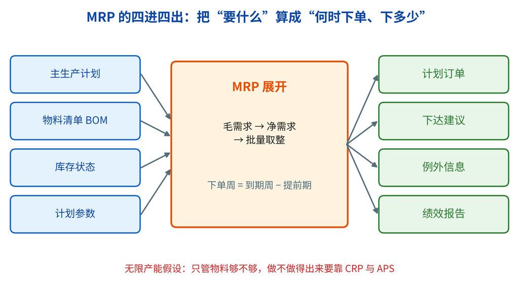

- **是什么**：四个输入进、四类输出出；MRP 只做一件事——把“要什么”算成“何时下单、下多少”
- **为什么**：没有库存状态与提前期，展开只给毛需求，给不出可执行的下达日
- **怎么判断输入可信**：MPS 不稳、BOM 不准、库存不实，三个坏一个，输出就不可信
- 先看例外信息：它说明哪个假设已经破了（下达日已过、提前期不足）

## BOM 是骨架：三要素与一次展开

> **判据**：BOM 能不能算料，看三件事——父子与用量、层级、物料属性（提前期／批量／损耗）。
- 示例结构：X＝1Z＋2Y，Z＝2Y＋1W；需 X 100 台

| 物料 | 所在层 | 单台用量 | 毛需求（需 X 100 台） |
| --- | --- | --- | --- |
| X | 0 | 1 台 | 100 台 |
| Z | 1 | 1 件 | 100 件 |
| Y | 1、2 | 2 件／2 件 | 400 件 |
| W | 2 | 1 件 | 100 件 |

- **为什么必须先算低层码**：Y 在第 1、2 层都出现，按层各算一次就会重复采购，LLC(Y)＝2
- 累计提前期＝最长路径：Y→Z→X＝2＋1＋1＝4 周，决定 X 的最早开工

## 库存状态文件：MRP 的账本

- 八个字段：现有库存、已分配量、在途量、安全库存、提前期、批量、损耗率、低层码
- 可用量 ＝ 现有库存 − 已分配量；MRP 只能用可用量做净算
- 在途量要按“预计到货周”落到时间轴，不能只记一个总数
- 安全库存是不得动用的底线，净需求公式里要先把它补回
- 批量规则决定“订多少”：直接批量、固定批量、经济批量、最小最大、期间订货量

| 规则 | 批量 | 平均周转库存 | 适用 |
| --- | --- | --- | --- |
| 直接批量 | 等于净需求 | 45 件 | 贵重、专用、需求不稳 |
| 固定批量 | 250 件 | 125 件 | 有最小包装或模具限制 |
| 经济批量 | 212 件 | 106 件 | 需求平稳、订货成本可估 |

- 算例：周需求 90 件、每次订货 500 元、单位周持有成本 2 元，$Q^{*}=\sqrt{2DS/H}=212$ 件
- 批量的代价：批量越大，周转库存越高，但换型与订货次数越少

## 低层码：为什么必须先算 LLC

- **低层码 LLC**：同一物料在产品结构中出现的**最低层号**
- 算法：沿每条路径下溯，取该物料出现层号的最大值
- 展开顺序：按 LLC 升序处理，父项算完再算子项，只汇总一次
- 反例：B 在第 1、2 层都出现，按层各算一次就会重复采购

| 物料 | 出现层 | LLC | 处理顺序 |
| --- | --- | --- | --- |
| P | 0 | 0 | ① |
| A | 1 | 1 | ② |
| B | 1、2 | 2 | ③ |
| C、D | 2 | 2 | ③（同层可并行） |

- $\mathrm{LLC}(B)=2$：B 的毛需求必须合并到第 2 层一次算清
- BOM 三要素：结构（父子与用量）、层级、物料属性
- 判据：LLC 算错，毛需求重复或漏算，库存与缺料同时出现

## MRP 计算逻辑：五步推出订单

| 步骤 | 计算 | 本步结果 |
| --- | --- | --- |
| ① 毛需求 | 独立需求＋相关需求 | 80 件（第 7 周） |
| ② 预计可用 | 现有＋计划接收−毛需求 | 50＋30−80＝0 |
| ③ 净需求 | $NR=\max(0,\ G+SS-OH-SR)$ | 80＋20−50−30＝20 |
| ④ 批量 | 按批量规则取整 | 20 件（直接批量） |
| ⑤ 倒排 | 接收周减提前期 | 第 5 周下达（提前期 2 周） |

- 毛需求来自 MPS（独立需求）与父项计划订单（相关需求），不是“预测多少就多少”
- 净需求公式：$NR=\max(0,\ G+SS-OH-SR)$；$G$ 毛需求、$SS$ 安全库存、$OH$ 现有、$SR$ 计划接收
- 批量取整后再倒排：$t_{rel}=t_{due}-LT$，$LT$ 为提前期
- 逐周滚动：本周的预计可用结转到下一周，出现负值才产生净需求
- 无限产能假设：MRP 只算物料，不管设备够不够，需要 CRP 补
- 例外优先：先处理“下达日已过”“提前期不足”，再看数量
- 读法：先看净需求是否大于零，再看批量把订单放大到多少

## MRP 算例：三层 BOM 的两轮展开

- 结构：P＝2A＋1B；A＝1B＋1C＋2D；B 外购。
- 条件：第 8 周需 P 100 台；库存 P20、A30、B40、C50、D60。
- 参数：提前期 P 2、A 1、B 2、C 3、D 1 周；批量 P、A 直批，B 100、C 100、D 200。

[output not shown]

- 关键一：A 毛需求＝P 计划订单 80×2＝160。
- 关键二：B 毛需求＝P 下达 80＋A 下达 130＝210，跨层只算一次。
- 关键三：D 毛需求＝A 下达 130×2＝260，批量 200 使期末归零。
- 算完先做期末校验：期末＝期初＋批量−毛需求，对不上就是表里有一行错。
- 校验：B 40＋200−210＝30；C 50＋100−130＝20。

## 累计提前期：订单该提前几周下

- **累计提前期**：从最底层采购到成品完工的**最长路径**时间
- 算法：每条从根到叶的路径求提前期之和，取最大值
- 用途：倒排计划订单下达日、确定 MPS 计划时界与冻结区
- 用途：判断接单能力——客户要 5 周、累计 7 周，只能靠库存或加急

| 物料 | 提前期 | 累计 | 第 10 周交货时的下达周 |
| --- | --- | --- | --- |
| P | 2 周 | 2 周 | 第 8 周 |
| A | 1 周 | 3 周 | 第 7 周 |
| C | 3 周 | 6 周 | 第 4 周 |
| D | 1 周 | 7 周 | 第 3 周 |

- 路径 P←A←C←D：2＋1＋3＋1＝7 周，D 最晚第 3 周下单
- 另一条 P←A←D 只有 4 周，不能当计划依据
- 计划时界不小于累计提前期，否则“冻结”是假的

## 能力需求：RCCP 与 CRP 的分工

- **RCCP 粗能力**：在 MPS 层只核关键工作中心，用资源清单估算。
- 三种算法：资源清单法、产能清单法、历史负荷法；精度低、速度快。
- **CRP 细能力**：在 MRP 层按计划订单、工艺路线、工作中心逐周核算。
- 可用能力＝设备数×班次×每班工时×工作日×效率（本例 0.8）。
- 负荷＝订单量×单件工时；负荷率＝负荷÷可用能力。
- 超载对策：加班、外协、调序、拆批；欠载对策：备货、支援、培训。

| 工作中心 | 可用工时 | 负荷工时 | 负荷率（措施） |
| --- | --- | --- | --- |
| WC1 | 180 | 198 | 110.0%（加班 18 h） |
| WC2 | 120 | 104 | 86.7%（支援 WC1） |
| WC3 | 90 | 96 | 106.7%（加班 6 h） |

- CRP 仍是无限产能的“事后校验”，真正的有限产能排程要 APS。

## MRPII 五层计划：谁定、管多久

- 五层：经营规划 → 销售与运作 → MPS → MRP → 车间与采购；每层回答“做多大生意 → 供需平衡 → 成品何时做 → 零件何时买 → 今天做什么”
- 逐层钩稽：上层一变，下层重算；责任分层：经营层、S&OP 会议、计划部、车间与采购

| 层次 | 计划期 | 粒度 | 主责 |
| --- | --- | --- | --- |
| 经营规划 | 3～5 年 | 年 | 总经理 |
| 销售与运作 | 1 年 | 月 | 跨部门会议 |
| MPS | 3～6 月 | 周 | 计划部 |
| MRP | 1～3 月 | 日／周 | 计划部 |
| 车间与采购 | 1～4 周 | 班／日 | 车间、采购 |

- MRPII 三次集成：物料与能力、计划与执行、业务与财务
- 闭环靠反馈：工单完工、采购到货、废品与工时必须回写；判据是**上周实绩**，不是上周会议
- 计划冻结：冻结区内只执行、不改计划，否则层层重排

## 模块（一）：六条链都落在同一本账上

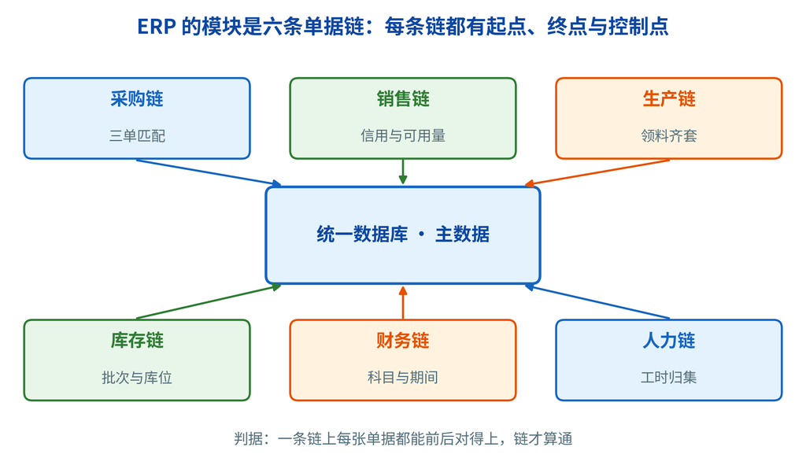

- **两条地基链**：财务（总账、应付、应收、成本）与生产（BOM、工单、排程、产能）
- 另外四条：销售、采购、库存、人力——各自有起点与终点，但共用一套主数据与凭证
- **判据**：先看地基链通不通——链断的地方报表一定对不上；每条链的单据要能双向追溯，把模块当“部门软件”各买各的，最后只能靠接口拼。

## ERP 的核心模块（二）：扩展与协同

| 模块 | 主要内容 | 主要使用者 |
| --- | --- | --- |
| 人力资源 | 招聘、培训、花名册、薪酬福利、离职交接 | 人事 |
| 项目管理 | 资源分配、成本预算、工作分解结构（WBS）、时间跟踪 | 项目组 |
| 客户关系管理 | 销售与市场策略、佣金、客户服务、呼叫中心 | 销售 |
| 合同与数据服务 | 合同全生命周期；客户／供应商／员工自助门户 | 商务、全员 |

- 趋势：ERP 从前台后台一体化角度吸收 CRM、SRM、商业智能（BI）
- 判据：模块再多，真正决定成败的仍是**财务与生产两块地基**

## 财务业务一体化：单据变凭证

- 核心机制是**自动记账**：业务事件按记账规则生成借贷分录，不靠会计手工录入
- 三个前提：科目表统一、记账规则可配置、业务单据带金额与数量
- 采购三单匹配：采购订单、收货单、发票三者数量与价格对上才付款
- 销售两头记账：发货记成本，开票记收入；成本与收入在同一期间配比
- 月末：折旧、摊销、费用分摊、在制与差异结转，关账后出三大报表

| 业务事件 | 借方 | 贷方 | 金额（元） |
| --- | --- | --- | --- |
| 收货 | 原材料 | 应付暂估 | 100,000 |
| 收票 | 应付暂估、进项税 | 应付账款 | 113,000 |
| 付款 | 应付账款 | 银行存款 | 113,000 |
| 发货 | 主营业务成本 | 库存商品 | 60,000 |
| 开票 | 应收账款 | 主营业务收入、销项税 | 169,500 |

- 判据：任意一张凭证都能“下钻”到业务单据；查不到源单的账，就是错账
- 期间关账：业务没记完账，财务不能结账；结账后的调整要走下期

## 报表与决策：从台账到驾驶舱

- 三层报表：操作层（单据）、管理层（汇总）、决策层（指标）
- 例外优先：先看红黄灯，再看明细；没有例外规则只是电子台账
- 指标三统一：定义、公式、数据源；两套口径，会议必吵架
- 常用：准时交付率、库存周转率、缺料率、成本差异率
- 工具：仪表板看趋势、OLAP（联机分析处理）切片、预测看误差、挖掘找相关

| 指标 | 公式 | 用途 | 陷阱 |
| --- | --- | --- | --- |
| 准时交付率 | 按期交付订单÷总订单 | 客户满意 | 改交期算不算违约 |
| 库存周转率 | 销货成本÷平均库存 | 资金效率 | 压库存伤交付 |
| 缺料率 | 缺料工单÷总工单 | 计划质量 | 只统计已发现的 |
| 成本差异率 | （实际−标准）÷标准 | 成本控制 | 标准多年不更新 |

- 决策支持是“异常→原因→动作”，不是多看报表
- 报表治理：一张报表一个 owner，口径变更留痕

## ERP 选型：四维评分与一票否决

- 四个维度：**功能匹配、行业适配、总拥有成本、实施能力**
- 功能匹配看覆盖度与关键程度，不看功能清单长短
- 行业适配看同行案例与模板：离散／流程、项目型／量产型差别大
- 总拥有成本＝许可或订阅＋实施＋开发＋硬件＋培训＋运维＋升级
- 实施能力看顾问、项目经理、同城服务与知识转移

| 维度 | 权重 | A 供应商 | B 供应商 |
| --- | --- | --- | --- |
| 功能匹配 | 35% | 80 | 90 |
| 行业适配 | 25% | 90 | 70 |
| 总成本 | 20% | 70 | 85 |
| 实施能力 | 20% | 85 | 60 |
| 加权总分 | 100% | 81.5 | 78.0 |

- 示例：A、B 加权 81.5 对 78.0；A 胜在行业与实施，B 胜在功能与价格
- 一票否决：数据不能本地化、合规不达标、无同行业案例
- 报价拆开比：许可、实施人天、二次开发、年运维

## 实施方法论：瀑布、敏捷与分步

- 瀑布式：立项 → 蓝图 → 实现 → 上线准备 → 上线与支持，阶段间有评审门
- 敏捷式：按业务场景切小迭代，2～4 周一个原型，边用边改，适合流程未定型
- 分步式：按模块、按工厂、按区域分批上线，每批都走一遍完整周期
- 选法判据：流程稳定选瀑布，需求不清选敏捷，多组织选分步

| 方法 | 适用 | 优点 | 风险 |
| --- | --- | --- | --- |
| 瀑布 | 流程稳定、合规强 | 可控、文档全 | 周期长、变更贵 |
| 敏捷 | 需求不清、试点 | 见效快、反馈快 | 范围易失控 |
| 分步 | 多工厂、多模块 | 风险分散 | 接口多、周期长 |

- 无论哪种方法，蓝图阶段必须回答：哪些流程改、哪些不改、谁签字
- 上线不是终点：上线后 3 个月是稳定期，要留驻场与快速响应
- 实施不是 IT 项目：业务 owner 签字才算验收，IT 只对系统质量负责

## 数据迁移：主数据清洗六步

- 六步：盘点 → 标准化 → 去重 → 补全 → 映射 → 试导。
- 顺序：物料、BOM、客户、供应商等静态数据先清，动态数据后清。
- 一物多码是头号杀手：同一颗螺钉三个编码，MRP 就会三次采购。
- 判据：一物一码、一客一码、单位统一、BOM 用量与损耗可核。

| 步骤 | 动作 | 产出 | 判据 |
| --- | --- | --- | --- |
| 盘点 | 导出全部主数据 | 清单 | 覆盖率 100% |
| 标准化 | 统一编码、单位、名称 | 编码规则 | 无同义异码 |
| 去重 | 按关键属性合并 | 唯一清单 | 无重复档案 |
| 补全 | 补提前期、批量、科目 | 可用档案 | 关键字段齐全 |
| 映射 | 旧码对新码 | 对照表 | 一对一可逆 |
| 试导 | 全量导入测试库 | 差异表 | 三本账对平 |

- 试导至少三轮：全量试导 → 对账 → 差异归零 → 再正式导。
- 对账三本账：库存数量、库存金额、总账余额；对不上不能上线。

## 上线切换：并行、直接与试点

- **并行运行**：新旧系统同时跑 1～3 个月，双份录入、双份对账，风险最低、成本最高
- **直接切换**：某一时点停旧启新，成本最低、风险最高，适合业务简单或旧系统到期
- **试点推广**：先一个工厂或一条产品线上线，跑通再复制，适合多组织集团
- 选择判据：业务连续性要求、数据质量、团队能力、时间窗口（月末、年末、旺季）
- 回退方案：切换前定好什么条件回退、回退到哪一天的数据、谁拍板

| 方式 | 成本 | 风险 | 适用 |
| --- | --- | --- | --- |
| 并行 | 高 | 低 | 财务、连续生产 |
| 直接 | 低 | 高 | 业务简单、旧系统到期 |
| 试点 | 中 | 中 | 多工厂、多业态 |

- 并行期的隐性成本：两套账对不上时，业务会挑对自己有利的那套
- 切换窗口避开月末结账与旺季；切换后第一周必须每日对账

**结论：切换方式取舍的是风险与成本，回退方案必须先于切换定好。**

## 项目组织：谁对 ERP 成败负责

- 三层组织：指导委员会、项目经理与项目管理办公室（PMO）、关键用户与顾问
- 一把手工程：不是挂名组长，而是能在部门冲突时拍板、能给资源
- 业务主导：流程 owner 对“改不改流程”负责，IT 对“系统怎么实现”负责
- 关键用户：每个模块至少一名懂业务、有威信、能全职投入的骨干
- 顾问：给方法与模板，不给“你们公司的答案”；知识转移写进合同
- RACI：谁负责、谁批准、谁被咨询、谁被告知，一张表说清

| 角色 | 职责 | 常见失位 |
| --- | --- | --- |
| 指导委员会 | 定目标、拍板、给资源 | 只开会不决策 |
| 项目经理 | 计划、范围、风险、沟通 | 无权跨部门 |
| 流程 owner | 流程设计与签字 | 挂名不参与 |
| 关键用户 | 需求、测试、培训 | 兼职、频繁换人 |
| 实施顾问 | 方法、配置、知识转移 | 包办代替 |

- 失败信号：项目组里全是 IT，业务部门只在验收时出现

## 常见失败模式：范围、数据、培训

- **范围失控**：什么都想上、边做边加需求，结果预算与工期双超
- **数据失真**：一物多码、库存不准、BOM 不全，系统算出“正确的错误答案”
- **培训不足**：上线后不会用、不敢用，最后回到 Excel 双轨运行
- 另外三个坑：一把手不投入、过度二次开发、测试与切换演练不足
- 早期信号：需求文档一周三改、主数据盘点拖过一个月、关键用户开始请假

| 失败模式 | 表现 | 根因 | 对策 |
| --- | --- | --- | --- |
| 范围失控 | 需求不断增加 | 没有范围基线 | 冻结范围、变更评审 |
| 数据失真 | 库存账实不符 | 主数据无人负责 | 设数据 owner、上线前盘点 |
| 培训不足 | 仍用 Excel | 培训走过场 | 分角色培训、考核上岗 |
| 过度定制 | 升级困难 | 流程迁就软件 | 先优化流程、少改代码 |
| 领导缺位 | 部门不配合 | 项目只当 IT 项目 | 一把手主持月度评审 |

- 失败模式会叠加：范围一乱，数据与培训必然崩
- 失败不是“系统不好”，多数是“管理与数据没准备好”

## ERP 与精益：先流程，后系统

- 精益先问“流程该不该存在”，ERP 再问“怎么固化”
- 顺序反了，就是把浪费电子化：七道手工签字原样搬进系统
- ERP 是计划（推），精益要流动与拉动（拉）；层次不同，不替代
- 上 ERP 前先梳理：删不增值审批、合并重复录入、统一口径
- 精益落点：节拍→产能，看板→补货点，平准→MPS，标准作业→工艺

| 精益原则 | ERP 对应 | 注意 |
| --- | --- | --- |
| 节拍 | 工作中心产能、工艺路线 | 参数要实测，不要拍脑袋 |
| 看板 | 补货点、最小最大库存 | 看板数量随需求调整 |
| 平准 | MPS 均衡、日产量 | 均衡不是平均，要匹配交付 |
| 标准作业 | 标准工时、工序 | 工时含宽放，口径统一 |
| 持续改善 | 参数与流程可配置 | 别把参数写死在代码里 |

- 上线后只是“录入更快”、没减少环节，就还没拿到精益收益
- 业务流程重组（BPR）不是裁员：流程简化后岗位要重新设计

## 制造费用：ERP 里怎么分摊

- 制造费用先归集到**成本中心**，再按动因分到工单与产品
- 预定分配率＝预算制造费用÷预算作业量；动因常用机器工时
- 已分配＝实际作业量×预定分配率；期末与实际比，得少分配或多分配
- 差异分解：耗费差异（花多了）＋产量差异（干少了）
- 差异处理：金额小进当期损益，金额大按比例分摊

| 项目 | 金额 | 说明 |
| --- | --- | --- |
| 预算制造费用 | 1,200,000 元 | 固定 600,000＋变动 20 元／时 |
| 预算机器工时 | 30,000 h | 分配率 40 元／h |
| 实际机器工时 | 31,500 h | 已分配 1,260,000 元 |
| 实际制造费用 | 1,302,000 元 | 少分配 42,000 元 |
| 差异分解 | ＋72,000／−30,000 | 耗费不利＋产量有利 |

- 单位成本：A 2.5 h→100 元；B 1.5 h→60 元
- 陷阱：用实际工时反算分配率，会把效率问题藏进成本

## MRP 与 JIT 混用：推拉的分界

- MRP 管计划：长周期、贵重、专用、需求离散的物料
- JIT（准时制）用看板管执行：短周期、重复、通用、消耗稳定的物料
- 分界点叫**解耦点**：之前推（按计划），之后拉（按消耗）
- 混合：MRP 算基准量与补货点，车间用看板触发，收货回冲
- 原则一：一套物料只能有一个补货信号，否则重复下单
- 原则二：计划订单不直接变工单，要经产能校验与执行确认

| 物料类型 | 计划方式 | 补货信号 | 库存策略 |
| --- | --- | --- | --- |
| 长周期进口件 | MRP | 计划订单 | 安全库存＋提前期 |
| 通用标准件 | 看板 | 看板卡 | 最小最大 |
| 客户定制件 | MTO／MRP | 订单 | 零成品库存 |
| 易变质件 | 看板／JIT | 消耗 | 小批量高频 |

- 判据：波动大、提前期长的用推；平稳、短的用拉

## SCM、CRM 与 ERP：三层的分工

- ERP 是交易后台：订单、库存、采购、生产、财务一次录入
- 供应链管理（SCM）是计划与协同：需求、网络、供应商、物流与库存
- CRM 是前台：线索、商机、报价、服务
- 三条接口：CRM→ERP 订单与信用；ERP→SCM 物料需求；SCM→ERP 采购订单
- 主数据归属：客户以 CRM 或 ERP 一方为主，物料与供应商归 ERP
- 陷阱：接口只传结果不传状态，订单改了、库存占了，两边对不上

| 系统 | 回答的问题 | 核心对象 |
| --- | --- | --- |
| ERP | 资源够不够、账对不对 | 订单、库存、工单、凭证 |
| SCM | 整条链怎么最优 | 需求、产能、运输、供应商 |
| CRM | 客户要什么、值多少 | 线索、商机、客户、服务 |

- 顺序：先把 ERP 交易与主数据打牢，再上 SCM 与 CRM

## 云 ERP 与国产化：部署再平衡

- 四种形态：本地、云托管、SaaS（软件即服务）、混合；差别在运维、付费、可改性
- SaaS 账要算全：订阅低，但集成、迁移、定制、退出可能更高
- 云强在快上线、按需扩容、版本统一；弱在深度定制与数据主权
- 国产化驱动：自主可控、等保、信创、服务响应，不等于全面替代
- 迁移风险：历史数据、接口、双轨期、习惯；先试点再全量
- 判据：总拥有成本（TCO）、连续性、合规三张表拉平，再谈价格

| 部署 | 付费 | 数据主权 | 适用 |
| --- | --- | --- | --- |
| 本地 | 许可＋运维 | 企业自控 | 流程复杂、数据敏感 |
| 云托管 | 订阅＋托管费 | 云商机房 | 中型企业、IT 弱 |
| SaaS | 按用户年订阅 | 多租户共享 | 标准化业务、快速上线 |
| 混合 | 组合 | 核心自控、外围云 | 集团多组织 |

- 真问题不是“换不换”，而是换完流程与数据能不能接上

## 案例：一次 MRP 结果的解读

- 场景：铸件 X 现有 30、安全库存 20、批量 100、提前期 2 周，当前第 4 周初。

| 周次 | 毛需求 | 预计可用 | 净需求 → 计划订单 |
| --- | --- | --- | --- |
| 第 4 周 | 40 | 90 | 30 → 100 |
| 第 5 周 | 120 | 70 | 50 → 100 |
| 第 6 周 | 60 | 110 | 10 → 100 |
| 第 7 周 | 0 | 110 | 0 → 0 |

- 读法：按提前期倒推——第 4、5、6 周三张单，下达周是第 2、3、4 周。
- 前两张已过期：能催则催，不能催就把需求挪到有料的时间。
- 第三张今天必须下；别急着改批量，先确认毛需求与在途。
- 三种例外：下达日已过、提前期不足、需求插入。
- 根因通常在数据：提前期设短了、在途没录、BOM 用量错了。
- 动作闭环：改计划 → 通知采购与车间 → 回写新交期 → 下周重算。

## 案例：库存下降的数据逻辑

- 教学算例：库存分周转、安全、在途三块；平均库存＝周转＋安全
- 改善前：批量 400、提前期 6 周、周需求 100、标准差 30、$z=1.65$
- 改善后：批量 100、提前期 4 周，其余不变

$$\bar I=\frac{Q}{2}+z\sigma\sqrt{L}$$

| 项目 | 改善前 | 改善后 | 变化 |
| --- | --- | --- | --- |
| 周转库存 | 200 | 50 | −150 |
| 安全库存 | 121 | 99 | −22 |
| 平均库存 | 321 | 149 | −172（−53.6%） |
| 在途库存 | 600 | 400 | −200 |

- 降库存不是“上系统”自动发生的：批量降 75%、提前期降 33%
- 杠杆排序：先降批量（换型），再降提前期（供应商与工艺）
- 只压库存不改善交付，缺料率会上升；库存与交付一起考核
- 含在途总库存从 921 降到 549，降幅 40.4%

## 四个角色：后台核心不控设备

> **判据**：ERP 在智能制造里的位置是**后台核心**——不控设备，但决定做什么、要多少、算多少钱。
- **财务智能化**：数据自动采集，成本实时可见 → 报价与预算不再滞后一个季度
- **供应链强化**：动态库存、自动补货、供应商评估 → 交期与库存同时改善
- **生产精细化**：计划、物料需求、过程跟踪 → 计划可执行、进度可追踪
- **库存协同**：与供应商／客户共享库存 → 缺货与积压同时下降
- 边界：ERP 出计划，MES 执行并回传；接口不清就会两头对不上

## ERP 的局限：五件它做不到的事

- **无限产能**：MRP 假设设备无限，计划可能做不出来，要靠 CRP 与 APS
- **固定提前期**：提前期被当常数，实际随批量、负荷、供应商变化
- **数据依赖**：主数据不准，算得越快错得越远；ERP 只放大数据
- **不产生知识**：记录“发生了什么”，不解释“为什么”
- **不管战略**：优化既有流程，不回答“该不该做这个产品”

| 局限 | 表现 | 补位 |
| --- | --- | --- |
| 无限产能 | 计划与车间脱节 | APS、MES |
| 固定提前期 | 交期承诺不准 | 供应商协同、动态提前期 |
| 数据依赖 | 账实不符 | 主数据治理、盘点 |
| 不产生知识 | 报表很多、洞察很少 | BI、精益改善 |
| 不管战略 | 流程高效但方向错 | 战略规划、PLM |

- 边界：ERP 是“把事记清楚、算清楚”的系统，不是“把事做对”的系统
- 所以要与 APS、MES、PLM 一起设计，不能指望它包打天下

## 复习要点：十个必会概念

- ① 定义：一个数据库、三类资源、一条主线，业务驱动记账
- ② 演进：MRP → 闭环 MRP → MRPII → ERP → ERPII
- ③ 四输入四输出；净需求 $NR=\max(0,G+SS-OH-SR)$
- ④ 低层码与累计提前期：决定展开顺序与下达日
- ⑤ 能力：RCCP 粗、CRP 细，负荷率＝负荷÷可用能力
- ⑥ 五层计划：经营规划、S&OP、MPS、MRP、车间与采购
- ⑦ 财务一体化：三单匹配、自动记账、凭证可下钻
- ⑧ 实施：选型四维、数据六步、切换三法、失败模式
- ⑨ 精益：先流程后系统；MRP 计划、看板执行
- ⑩ 边界：无限产能、固定提前期、数据依赖

## 推导留给 AI：ERP（汇总）

> 上一页收完十个必会概念；接着把问题推到边界，留四问。
- 用一句话定义 ERP，并指出它与“财务软件＋进销存”的三点区别
- 自拟一个两层 BOM 与批量规则，算一遍 MRP 的净需求与下达周（列出全部假设）
- ERP 实施为什么必须“业务主导”？从数据质量与流程优化两个角度论证
- 无限产能假设在什么场景下会失效？失效后应引入什么机制

**结论：四问的答案都要写出假设与口径，能复算才算会。**

## 本部分小结：一条主线三组公式

- 一条主线：**需求 → 计划 → 能力 → 执行 → 成本 → 账**；价值在“一条线不断”
- 第一组物料计划：$NR=\max(0,G+SS-OH-SR)$，$t_{rel}=t_{due}-LT$
- 第二组能力平衡：$\rho=L/C$；超载先调序、再加班、最后外协
- 第三组库存与成本：$\bar I=Q/2+z\sigma\sqrt{L}$；差异＝实际−标准
- 三个“不”：不把 ERP 当财务软件、不把 MRP 当排程、不把上线当终点
- 三个“先”：先流程后系统、先数据后功能、先试点后推广
- 下部分：MES——把计划落到工位、设备与批次上

# 第三部分 · 第 3 内容块：MES 制造执行系统

- MES 的定位：ERP 与设备之间的执行层，负责把计划变成工位动作
- MES 的 MESA 十一项功能与三个目标：防错、改善、追溯
- 防错怎么落地（六类防呆）、改善怎么闭环（从异常单到标准作业）
- 三个可算的例子：追溯范围、OEE、数据采集口径；MES 与精益生产的关系

## MES：计划与设备之间的执行层

> 上一页给出本内容块的四条主线；这里先定 MES 的位置。

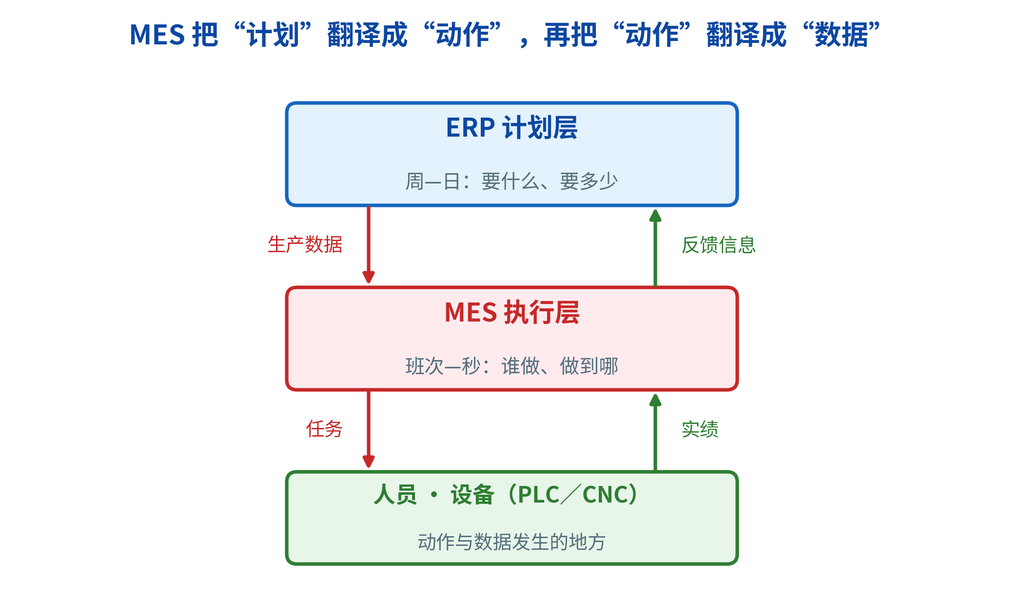

- **是什么**：执行层——把 ERP 的计划翻成工位动作，再把动作翻成数据
- **为什么**：计划到周、现场到秒，中间没有这一层，计划就是盲计划
- **怎么判断**：任取一个工单，能否答出“哪道工序、谁、哪台设备、何时、结果如何”
- 两条流向：向下是任务（做什么／怎么做／多久完成），向上是实绩（做了什么／怎么做的）

## MES 的发展：从单功能到 MESA 与 ISA-95

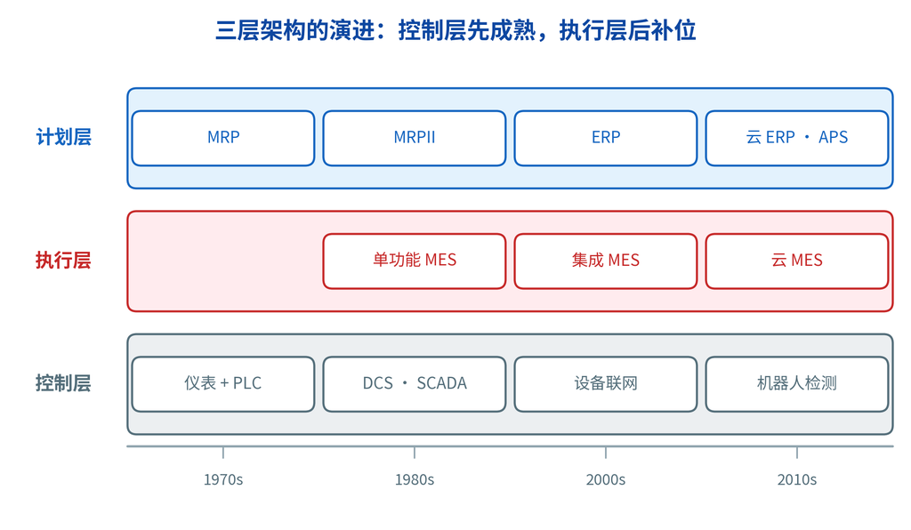

## MESA 十一功能模型：一组车间问题的答案

- MESA（MESA International）在 1990 年代给出 MES 的十一项功能，后来成为选型与验收的通用清单
- 十一项不是十一个模块，而是**十一类必须回答的问题**；小系统可以合并实现，但不能没有答案
- 分五组记：计划派工、执行跟踪、质量过程、设备人员、绩效分析
- 最容易被漏掉的是文档管理与人员管理：它们不直接产生数据，却决定执行是否合规

| 组 | 含哪些功能 | 回答的问题 |
| --- | --- | --- |
| 计划与派工 | 资源分配与状态、工序详细排程、生产单元派工 | 谁在什么设备上做、先后顺序如何 |
| 执行与跟踪 | 文档管理、数据采集、产品跟踪与谱系 | 按哪个版本做、做了什么、料从哪来 |
| 质量与过程 | 质量管理、过程管理 | 合不合格、参数是否受控 |
| 设备与人员 | 维护管理、人员管理 | 设备能不能用、人有没有资格 |
| 绩效 | 绩效分析 | 昨天损失在哪、今天改什么 |

- 用法：拿这张表做需求清单，逐项标“有／部分有／没有”，比听供应商演示可靠

## ISA-95 五层模型：MES 站在第三层

- ISA-95（IEC 62264）用**层级**划分企业信息系统，回答“哪个系统该管多细、多快”
- 判断归属看两件事：**时间尺度**（周／分／秒／毫秒）与**对象**（订单／工单／设备／执行机构）

| 层级 | 名称 | 典型系统 | 时间尺度 |
| --- | --- | --- | --- |
| L4 | 业务计划与物流 | ERP／MRPII | 周—月 |
| L3 | 制造运营管理（MOM） | MES／WMS／LIMS | 班次—小时—分钟 |
| L2 | 监控与数据采集 | SCADA／HMI | 秒—分钟 |
| L1 | 传感与控制 | PLC／DCS | 毫秒—秒 |
| L0 | 物理生产过程 | 设备、产线、物料 | 实时 |

- L3 是 MES 的家：生产、维护、质量、库存四类运营活动都在这一层协同
- 与三层说法对照：计划层对应 L4，执行层对应 L3 与部分 L2，控制层对应 L1／L0
- 边界争议的判据：**谁的时间尺度更紧，谁就该拥有这段逻辑**（停机判定放 L2，停机原因归类放 L3）

## MES 的目标：防错、改善、追溯

**防错（过程不要错）**

- 按工艺路线流转：条码校验、上料比对、工站防呆，减少跳站、漏测、错料
- 判定：同类低级错误（漏工序、错物料）在 3 个月内降到零

**改善（错了能变好）**

- 实时指标与异常预警：及时停线、及时处理，为品质与效率改善提供依据
- 判定：改善前后用同一指标对比（不良率、节拍、停机时间）

**追溯（错了能说清）**

- 正向：原料 → 工单 → 成品 → 客户；反向：客户投诉 → 工单 → 人机料法
- 判定：能在小时级锁定批次与范围，而不是天级翻台账

> 防错管“别错”，改善管“变好”，追溯管“说清”——三者缺一，MES 就退化成电子台账。

## MES 防错：六类防呆与三个层次

- 防错目标不是“提醒人小心”，而是让错误**做不出来、流不出去**（不产生、不传递、不流出）
- 三个层次：**流程**（按工艺走）、**状态**（不符则禁止）、**标识**（条码唯一）

| 防错对象 | 典型规则 | 拦截的错误 |
| --- | --- | --- |
| 人 | 岗位权限、上工扫码 | 无证上岗、串岗 |
| 料 | 批次与原料条码校验、BOM 上料比对 | 错料、混批 |
| 顺序 | 前道未过站禁止后道开工 | 跳站、漏工序 |
| 规格 | 宽、长、厚与批次检验 | 规格不符 |
| 数量 | 发料数量校验、称重复核 | 多发、少发 |
| 记录 | 条码自动打印、牌号自动扫描 | 写错、记错 |

- 装置：条码／RFID（射频识别）校验、工站互锁、报警灯、换型点检表
- **三级强度**：提示 → 警告（需主管授权）→ 阻断（系统拒绝）；安全用阻断、效率用提示
- 判据：同类错料与漏工序事件 3 个月归零；每次拦截都有记录可查

## MES 改善：从异常单到标准作业

- 改善闭环五步：发现异常 → 记录事实 → 分析主因 → 实施与验证 → 标准化
- 三类数据源：报警与停线记录、不良代码与 SPC 失控点、OEE 损失项
- 预警体系三要素：**条件**（阈值／趋势规则）、**方式**（邮件、短信、看板、声光）、**平台**（记录与升级）

| 环节 | 输入 | 动作 | 证据 |
| --- | --- | --- | --- |
| 发现 | 报警、停线 | 记录时间、工位、批次 | 异常单 |
| 分析 | 异常单、帕累托图 | 分层排序找主因 | 主要原因排序 |
| 措施 | 主因 | 改防错、参数或工艺 | 措施单与责任人 |
| 验证 | 前后数据 | 同指标对比 | 不良率、停机时间 |
| 标准 | 验证结果 | 修订作业指导书 | 文件与培训记录 |

- 两级改善：班组日常改善（提案、品管圈 QCC）与跨部门专项（重复问题转 8D）
- 判据：改善前后用**同一指标**对比，且标准文件已更新；只改现场不改文件等于没改

## 生产追溯：批次、序列号与正反向

- 两种颗粒度：**批次级**（LOT，成本低、范围大）、**序列号级**（SN，成本高、范围小）
- 正向追溯：来料批次 → 工单 → 工序记录 → 成品 SN → 包装 → 客户
- 反向追溯：客诉 SN → 工单 → 设备与人员 → 参数 → 来料批次 → 供应商
- 每条记录四要素：**人、机、料、法**，外加统一时间戳与不可篡改的写入方式
- 算例：一批关键件投在 4 个批次共 2,000 台成品上；只能追到批次就得全召回 2,000 台；追到 SN 并叠加“同批物料＋同设备＋同时段”，可缩到 120 台，**范围降 94%**
- 三个断点：手工补录、批次混用、返工品未重新绑定
- 判据：一次反向追溯在**小时级**完成，且能输出受影响客户清单

## 追溯算例：从 1,200 台锁定到 480 台

工单 WO-240506 装配 1,200 台，关键件 X 用了两个来料批次：L240423 对应 720 台、L240428 对应 480 台。供应商通知 L240428 中有 20 件存在缺陷。

| 步骤 | 做法 | 结果 | 单位 |
| --- | --- | --- | --- |
| 反向追溯 | 成品 SN 与物料批次绑定反查 | 锁定 480 台 | 台 |
| 客户分布 | 按发货记录分摊 | 甲客户 400 台、乙客户 80 台 | 台 |
| 全量返工成本 | 1,200 台 × 150 元/台 | 18.0 | 万元 |
| 精确返工成本 | 480 台 × 150 元/台 | 7.2 | 万元 |
| 节省 | 18.0 － 7.2 | 10.8（60%） | 万元 |

- 若追溯只到工单级，就只能全量召回；**追溯颗粒度直接决定质量成本**
- 本例假设：单台返工成本 150 元，未计客户停线损失（后者通常更大）

## 工单管理：下达、派工、报工、关单

- 工单是 MES 的**最小管理单元**，也是 ERP 与 MES 之间最重要的一条数据
- 拆分：一张 12,000 件的订单按 500 件批量拆成 **24 张工单**，每张可独立派工与结算
- 生命周期：创建 → 下达 → 派工 → 开工 → 报工 → 完工入库 → 关单
- 下达看三件事：物料齐套、工艺路线已发布、设备与工装可用；缺一项就应拦在下达前
- 派工到工序与工位：明确设备、班次、人员、计划起止时间与优先级
- 报工记六项：良品、不良（含代码）、工时、物料消耗、设备、批次或序列号
- 关单条件：数量收齐或短溢装审批、余料退库、不良品处理完毕、工时已审
- 常见错误：工单开了不关（在制品虚高）、报工只报数量不报不良代码（追溯与改善都断）

## 工序与工艺路线管理：把路线变成可执行步骤

- 工艺路线（Routing）＝工序序列＋每序的工位与设备＋标准工时＋检验点＋物料投入点
- 三层结构：路线 → 工序 → 工步；MES 的执行粒度通常到工序，防错粒度到工步
- 工艺路线是**受控主数据**：有版本、有生效日期、有变更单，不能在现场随手改
- 与 ERP 的关系：ERP 用路线算能力与标准成本，MES 用路线派工与报工，**必须是同一份**
- 与 PLM 的关系：MBOM 与工艺由 PLM 或工艺系统发布，MES 只消费不创作
- 组合爆炸：5 道工序、每道 2 台可选设备，理论路径 $2^{5}=32$ 条，路线管理要能约束而不是穷举
- 替代与返修路线：返工、返修、拆解要有独立路线与独立报工，否则良率与工时全部失真

## 生产调度与排产接口：APS 排、MES 执行

- 分工：**APS 回答“按什么顺序做”**（有限产能、换型最优），**MES 回答“实际做到哪”**（执行与反馈）
- APS 下发：工序级计划开始与结束时间、设备指派、工装与人员需求、物料需求时点
- MES 回传：实际开工与完工、设备状态与停机、良品与不良、缺料与质量异常
- 重排触发：设备故障、缺料、插单、质量停线、人员缺岗；不必每件事都全量重排
- 重排频率建议：每班一次全量加事件触发局部；全量重排过频会让现场觉得“计划天天变”，失去权威
- 接口要点：**版本号与时间戳**——现场必须知道手上这张派工单是第几版
- 判据：计划变更后 10 分钟内，工位终端与看板同步显示新顺序，且旧版可追溯

## 数据采集：条码、RFID、设备与 PLC

- 四条通道：条码、RFID、设备接口（PLC／OPC UA）、手工录入
- 采集服务器统一时标与编码；能自动就不手工，**自动采集率**决定数据可信度

| 通道 | 典型场景 | 主要限制 |
| --- | --- | --- |
| 条码 | 上料比对、过站、包装 | 依赖人扫，漏扫靠防错兜住 |
| RFID | 托盘、周转箱、在制品 | 成本高，金属环境有干扰 |
| 设备接口 | 参数、状态、产量、报警 | 老设备无接口，需改造 |
| 手工录入 | 检验值、异常描述、补录 | 及时性与真实性最弱 |

**结论：没有一种通道通吃，按对象选——单件用条码、托盘用 RFID、参数用设备接口。**

## 数据采集：先统一时标，再谈分析

> 上一页比了四条采集通道；这里看数据汇到哪里、怎样统一。

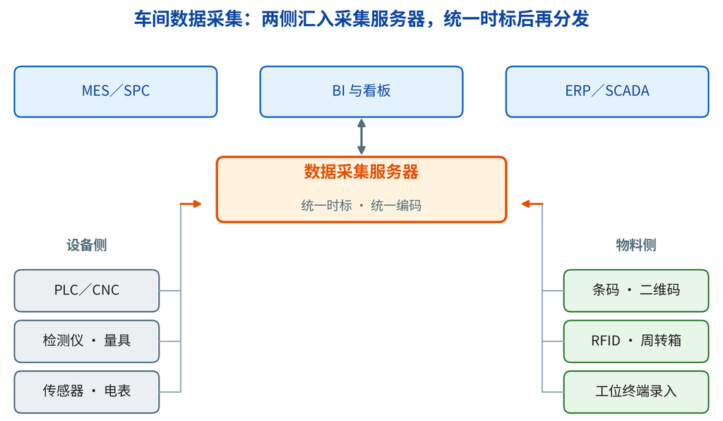

- **是什么**：两侧数据先汇到采集服务器，统一时标与编码，再分发到 MES、SPC、看板与 ERP
- **为什么**：不统一时标，同一时刻的数据对不上，追溯与 SPC 全部失效
- **三条路径**：设备接口（PLC／OPC UA）、扫码／RFID、手工录入；能自动就不手工
- **怎么判断**：同一参数在设备、MES、报表三处读数一致，才算可信

## MES 数据治理：采集频率与数据质量

- 采集频率由**用途**决定，不由设备能力决定：控制要秒级，绩效要分钟级，成本要班次级
- 算例：200 个测点、1 Hz、每天 16 h，则 1,152 万条/天；每条 100 B 约 1.15 GB/天，300 天约 346 GB/年
- 治理三招：边缘聚合（降频）、死区压缩（变化才记）、分层留存（原始 7 天，聚合 3 年）
- 数据质量六维：完整性、准确性、及时性、一致性、唯一性、有效性
- 最常见的四类脏数据：时间戳不统一、编码不统一、单位不统一、人工补录无痕迹
- 责任要落到岗：谁产生、谁校验、谁归档；MES 里要有“数据质量看板”
- 判据：同一班次的产量，在工位、MES、ERP 三处能对上；对不上要能查出在哪一步断的

## 质量管理：首检、巡检、终检与 SPC 接口

- 三类检验点：**首检**（换型或开班后第一件，防批量错）、**巡检**（按频次抽样，防过程漂移）、**终检**（出货前把关）
- MES 管“检验任务与记录”，SPC 管“控制图与判异”，靠接口分工而不是互相替代
- 首检未通过则**锁定工单**：这是 MES 最有效的一条质量互锁
- 巡检要带频次与路径：到点提醒、超时升级，否则巡检表永远事后补
- 接口字段：检验项目、规格上下限、实测值、判定、不良代码、责任工序
- 能力算例：$\bar{x}=10.02$、$s=0.012$、规格 $10.00\pm0.05$，则 $C_{p}=1.389$、$C_{pk}=0.833$——**均值偏移**是主因
- 判读：$C_{pk}<1.33$ 时先纠偏再降波动；只加严检验解决不了能力问题

## 物料与在制品管理：线边库、齐套与 FIFO

- MES 管三类物料状态：**线边库存**、**在制品（WIP）**、**已耗用**；线边以内归 MES，线边以外归 WMS
- 齐套检查在下达前做：按 BOM 展开算缺件，缺一件就不派工，避免开了工等料
- 上料防错：扫描物料条码与 BOM 比对，批次不符或超期即拦截
- FIFO（先进先出）与有效期：按入库时间与保质期排序，超期料自动冻结
- 在制品可视化：工序间 WIP 数量与停留时间，是找瓶颈最快的一张表
- 利特尔法则：在制品等于产出率乘以流程时间；产出率 1.25 件/min、流程时间 240 min，则 $WIP=1.25\times240=300$ 件
- 若流程时间压到 180 min，WIP 降到 225 件（$-25\%$），**不必买设备也能提产出**
- 盘点：MES 的 WIP 与实物差异要有日清机制，差异超阈值就停线复盘

## 安灯与异常响应：把停线变成有流程的事件

- 安灯（Andon）的本质不是灯，而是**“谁在多久内必须到场”的契约**
- 三级信号：绿（正常）、黄（求助，可继续生产）、红（停线，必须处置）
- 呼叫类型：缺料、设备故障、质量问题、工艺参数异常、人员支援
- 响应链示例（时限由企业自定）：操作工呼叫 → 班组长（3 min）→ 工艺或设备（10 min）→ 值班经理（20 min）
- MES 记录四件事：呼叫、到场、处置措施、恢复；由此得平均响应时间与平均修复时间
- 算例：节拍 20 s（3 件/min），停线 30 min 损失 90 件；单件毛利 80 元，一次停线约 7,200 元
- 升级规则要写死：超时未响应自动升级，不依赖人打电话
- 判据：安灯记录能按“原因—工位—班次”排序，才谈得上改善

## 绩效分析：产量、效率与良率

- 四个基本指标：**产量**（件）、**达成率**（实际／计划）、**良率**（良品／产出）、**效率**（标准工时／实际工时）
- 算例：计划 1,000 件、产出 1,100 件、良品 1,067 件、报废 15 件、返工 18 件

| 指标 | 计算 | 结果 | 读法 |
| --- | --- | --- | --- |
| 计划达成率 | $1100/1000$ | 110.0% | 超额，但要查是否牺牲了换型 |
| 良品率 | $1067/1100$ | 97.00% | 与 98% 的目标差 1 个点 |
| 报废率 | $15/1100$ | 1.36% | 直接成本损失 |
| 返工率 | $18/1100$ | 1.64% | 隐性工时与产能损失 |
| 一次合格率 | $1067/1100$ | 97.00% | 返工是否回算产出，决定两率是否同值 |

- 口径纪律：达成率按“入库良品”还是“下线数量”算，必须在制度里写死
- 效率看标准工时：实际工时高于标准工时，问题通常在方法或设备，不在工人
- 绩效用于**找损失**，不是用于扣钱；一旦用于扣钱，数据一定失真

## MES 绩效：OEE 算例

已知：计划运行时间 480 min，停机 48 min；理论节拍 30 s/件；实际产出 720 件，其中良品 684 件。

- 可用率 $A=\dfrac{480-48}{480}=90.0\%$
- 性能 $P=\dfrac{720\times0.5\ \text{min}}{480-48\ \text{min}}=\dfrac{360}{432}=83.3\%$
- 良品率 $Q=\dfrac{684}{720}=95.0\%$
- 设备综合效率 $\text{OEE}=A\times P\times Q=0.7125=71.25\%\approx71.3\%$
- 判读：经验口径以 85% 为世界级水平 → 本线主要差距在**性能**（换型与微停）
- 数据来源：时间来自状态监控、产量来自计数、良品数来自检验；停机原因当场选码，不许事后回忆。
- 行动顺序：先补性能（换型改善、减少微停），再提良品率，最后才扩产能

## 文档与 SOP 下发：让工位看到唯一有效版本

- 工位需要的文档：SOP、检验标准、图纸与关键尺寸、换型点检表、安全规程
- 核心问题不是“有没有文档”，而是**工位上那一份是不是当前有效版本**
- 做法：文档由 PLM 或文控系统受控发布，MES 按“产品＋工序＋工位”自动推送，版本号与生效日期可见
- 变更闭环：ECN 生效 → 文档换版 → MES 推送 → 操作工**签收确认** → 旧版自动失效
- 纸质对照：以 120 工位、每工位 8 份计共 960 份；一次换版要人工替换 960 份，且无法证明换全了
- 电子下发的价值：换版一次点击完成，签收记录可查，培训与考核可追溯到人
- 判据：抽查任一工位，能在 10 秒内看到版本号、生效日期与签收人
- 常见失败：把 PDF 挂到共享盘就称“电子化”——没有受控版本与签收，等于没有

## 人员与权限管理：谁能做、能做什么

- 两条线：**资格**（会不会）与**授权**（许不许），MES 必须同时管
- 资格：技能矩阵（工位 × 等级）、培训记录、上岗证有效期；到期自动禁止派工
- 授权：角色—功能—数据范围三层；操作工只看本工位，班组长看本线，工艺看全线
- 关键控制点：报工、改判、报废、超投料、参数修改、追溯查询，六类操作必须留痕
- 权限原则：**最小必要加职责分离**——申请报废与审批报废不能是同一人
- 登录方式：工牌、账号或扫码上岗；共用账号等于没有追溯
- 排班与工时：班次、出勤、间接工时（开会、培训、等待）要能分开记
- 判据：任一条追溯记录都能定位到具体的人，而不是“夜班组”

## MES 与其他系统集成：ERP、PLM、WMS、SCADA

- 集成的本质是**主数据一致、事件时序正确、异常可对账**，不是“接口能通”
- 四个主要对象：ERP（计划与财务）、PLM（产品定义）、WMS（线边以外库存）、SCADA（实时数据）

| 系统 | 方向 | 主要内容 | 时点 |
| --- | --- | --- | --- |
| ERP | 双向 | 工单、BOM、完工入库 | 下达实时，回传班次 |
| PLM | PLM→MES | MBOM、工艺路线、ECN | 变更生效时 |
| WMS | 双向 | 领料、退料、补货、入库 | 实时或按任务 |
| SCADA | SCADA→MES | 状态、参数、产量、报警 | 秒级 |

- 六类主数据先统一：物料、BOM、工艺路线、设备、工位、人员编码
- 接口三要素：协议（谁推谁拉）、时点（实时／班次／日结）、异常（重试与人工补录）
- 判据：日志可查、差异可对账、对不上有责任人——三条缺一，集成就靠人肉补

## MES 选型与实施：评分、分期与失败原因

- 选型先定需求：用 MESA 十一项标“必须／最好有／不需要”，再谈产品
- 加权评分：功能 30%、集成 25%、实施 20%、成本 15%、服务 10%

| 供应商 | 加权得分 | 强项 | 风险 |
| --- | --- | --- | --- |
| 甲 | 7.45 | 成本低、功能够用 | 集成能力弱 |
| 乙 | 7.50 | 功能与集成均衡 | 报价高、周期长 |
| 丙 | 7.25 | 集成与实施强 | 成本最高 |

- 差距小于 5% 别只看分数：看同行业案例、团队稳定性、能否分期上线
- 实施五阶段：调研 → 蓝图与主数据 → 试点线 → 推广 → 运维；先报工与追溯，后排产与绩效
- 失败主因：当纯技术项目、指望它改造流程、贪大求全、缺高层推动与培训
- 一句提醒：**MES 是锦上添花，不是雪中送炭**，它不替企业改流程

## MES 与精益生产：用数据支撑现场改善

- 精益回答“应该怎样流动”，MES 回答“流动得怎么样、哪里断了”
- 客户节拍：需求 600 件/天、可用 450 min（27,000 s），节拍 $=27000/600=45$ s/件
- 对照：设备理论节拍 20 s/件（3 件/min、180 件/h），能力是需求的 2.25 倍——**瓶颈不在设备**
- 现场改善三件事：把节拍对齐客户需求、把在制品压到上限以内、把异常响应时间缩短
- 看板与标准作业：队列与领料服从看板上限；节拍、作业顺序、标准手持量用实测数据校验
- **八大浪费的数字化对策**：过量生产→按看板上限排产；等待→齐套与缺料预警；搬运→条码定位与上料比对；过分加工→首件加 SPC 替代全检；库存→在制品上限；动作→自动采集；返工→参数监控与追溯；管理浪费→流程线上化、报表自动生成
- 判据：上线一年后看线边库存、停机时间、交付周期三项，而不是看报表数量

## 数字孪生与 MES：模型、实时性与边界

- 数字孪生＝物理对象的**模型、实时数据与双向连接**；MES 提供其中的执行数据与工单上下文
- 三个层次：设备孪生（状态与参数）、产线孪生（节拍与瓶颈）、工厂孪生（产能与物流）
- 主要用途：虚拟调试（上线前试跑）、排产方案验证、异常预测、培训与演示
- 实时性算例：传感 100 ms 加边缘处理 200 ms 加模型计算 500 ms，合计 800 ms
- 对照控制周期 50 ms：孪生慢 16 倍，**不能进闭环控制**，只能做监控、优化与预警
- 边界：控制回路归 PLC（L1），实时监视归 SCADA（L2），孪生与优化归 L3／L4
- 数据前提：模型参数（节拍、故障率、换型时间）必须由 MES 实测数据校准，否则只是动画
- 判据：孪生给出的建议能被 MES 执行并验证效果，否则只是展示

## 案例：某车间 MES 上线前后

- 背景（教学案例，数据为示意）：机加装配混线，120 工位，两班制，原用纸质流转卡加 Excel 报工
- 上线范围：工单与报工、条码过站、追溯、安灯、OEE 看板；排产仍由计划员手工

| 指标 | 上线前 | 上线后 | 变化 |
| --- | --- | --- | --- |
| 报工耗时 | 120 min | 10 min | $-92\%$ |
| 在制品 | 1,200 件 | 800 件 | $-33\%$ |
| OEE | 65% | 78% | ＋13 个百分点 |
| 一次追溯 | 4 h | 10 min | $-96\%$ |
| 盘点耗时 | 8 h | 2 h | $-75\%$ |

- 没变的部分：换型时间、设备故障率——这些要靠工艺与 TPM，软件替不了
- 教训：先做“记录与追溯”，再谈“优化与排产”，收益更容易兑现

## MES 的价值：两组行业调查

| 获益项目 | 1993 年调查 | 1996 年调查 |
| --- | --- | --- |
| 缩短产品制造周期 | 45%（2%～80%） | 35%（10%～80%） |
| 减少或消除数据输入时间 | 75%（25%～100%） | 36%（0%～90%） |
| 减少在制品数量 | 17%（25%～100%） | 32%（0%～100%） |
| 减少或消除作业转换文书 | 56%（5%～100%） | 67%（0%～200%） |
| 缩短产品交付周期 | 32%（2%～60%） | 22%（0%～80%） |
| 改进产品质量（减少次品） | 15%（5%～25%） | 22%（0%～60%） |

- 读懂这张表：收益最直接的是**替代纸面与 Excel**（数据录入、文书），其次是周期与在制品
- 质量与交付的收益需要**流程配套**，不会随软件上线自动发生
- 括号内为调查样本的获益范围，跨度很大，说明实施水平差异巨大

## 边缘计算与云 MES：把算力放在哪里

- 边缘计算：在车间侧完成采集、清洗、聚合、实时判定，只把结果与必要原始数据上传
- 云 MES：多工厂统一部署、按需扩容、远程运维；代价是时延与断网风险
- 带宽算例：200 测点 × 1 Hz × 50 B＝10 kB/s（36 MB/h）；边缘按 1 min 聚合后为 3.33 条/s，**降 60 倍**
- 选型判据：**控制与安全留在边缘，管理与分析放到云**，形成混合架构
- 断网设计：边缘缓存不少于 24 h，恢复后断点续传，工单与报工不因网络中断而丢
- 云的三笔隐性成本：数据出口费、专线或 VPN、驻场集成与运维人力
- 合规：生产数据与员工数据的跨厂、跨境流转要先过合规，再谈架构
- 判据：断网 1 h，产线不停、数据不丢、恢复后账能对上

## MES 复习要点：六条主线与四个易错点

- 一句定义：MES 在计划层与控制层之间，把计划变成动作、把动作变成数据
- 两个标准：MESA 十一功能管功能清单，ISA-95 五层管层级边界
- 三个目标：防错、改善、追溯——分别对应“别错、变好、说清”
- 四个核心对象：工单、工序与路线、物料批次、设备
- 五个接口方向：ERP、PLM、WMS、SCADA、APS
- 六个关键指标：达成率、良率、OEE、WIP、响应与修复时间、追溯时长

| 易错点 | 常见误解 | 正确说法 |
| --- | --- | --- |
| MES 的位置 | 是 ERP 的子系统 | 二者平级，分属 L3 与 L4，靠接口协作 |
| 上线的收益 | 上了 MES 就能提效 | 先有流程与主数据，MES 只做信息化 |
| 追溯的字段 | 字段越多越好 | 按用途取最小必要，留存期与成本挂钩 |
| OEE 的口径 | OEE 高就是好 | 要看是否牺牲换型与交付，口径须一致 |

- 复述法：合上讲义，按“一二三四五六”默写，再对照本页查漏

## 推导留给 AI：MES（汇总）

- 用四要素（人机料法）描述一条追溯链，指出最小必要字段与留存期限
- 自拟一组数据算 OEE，并给出三条改善措施的优先级（用计算说明）
- MES 与 ERP 的五个接口中，哪一个时点最容易出错？给出异常处理流程
- 若企业只想提高“数据录入效率”而暂不优化流程，MES 的收益会落在哪几项

## 本部分小结：定义、功能、边界与判据

- 一条主线：**计划 → 工单 → 工序 → 采集 → 追溯 → 绩效**，MES 把这条链上每一步都留下记录
- 功能观：MESA 十一项是“必须回答的问题”，不是必须买的模块
- 边界观：ISA-95 的 L3 是 MES 的家；L2 管实时监视，L4 管计划与财务
- 集成观：主数据一致、事件时序正确、异常可对账——三条缺一，集成就靠人肉补
- 价值观：先记录与追溯，再优化与排产；收益按记录类、管理类、物理类递减
- 三条判据：断网不停产、追溯小时级、口径三处一致

| 层次 | 问题 | 本部分的答案 |
| --- | --- | --- |
| 是什么 | MES 在哪一层 | 计划与控制之间的 L3 执行层 |
| 做什么 | 十一项功能怎么用 | 当需求清单与验收依据 |
| 凭什么 | 收益怎么证明 | 追溯时长、OEE、WIP、报工工时 |

- 下一部分：PLM 与系统集成，把“产品定义”这一源头接上

# 第四部分 · 第 4 内容块：PLM 与系统集成

- PLM（产品生命周期管理）的定位：产品定义的权威源，覆盖从概念到退市
- PLM 与 PDM、BOM（EBOM／MBOM／SBOM）、协同开发与并行工程
- 两个分析工具：产品开发漏斗、甘特图；一个 ECN 的跨系统流转
- 伦理落点：数据采集与员工隐私、追溯与监控的边界

## 案例：产品管理失控的四次代价

> 上一页拉开 PLM 这一部分；这一页先看产品失控的代价，再讲怎么管。

| 时间 | 对象 | 失控环节 | 后果 |
| --- | --- | --- | --- |
| 2008 | 雷曼兄弟 | 高杠杆金融产品的全链条风险 | 破产 |
| 2008 | 三鹿集团 | 质量数据与追溯链条 | 数千名婴儿患肾结石 |
| 2011 | Netflix | 取消 DVD 租赁、拆分 Qwikster 并涨价 | 用户抗议流失、股价暴跌 |
| 2019 | 波音 737 MAX | MCAS 设计缺陷叠加认证管理失控 | 两架坠机、346 人死亡 |

- 共同点：不是单点技术错误，而是“需求—设计—变更—认证—交付”链上某一环失去数据与控制
- 行业跨度：金融、食品、互联网、航空都栽在同一件事上——数据没有唯一权威源
- 六类挑战：数据管理、跨部门跨组织协作、变更管理与市场投资、技术与标准整合、数据安全与知识保护、技术与人员培训
- 智能制造把软件、算法、供应商数据都装进产品，链条更长，单一数据源更要紧
- 判据：一次产品事故要能用数据复现“当时用的哪一版、谁批准的、装在哪台”

**结论：PLM 的价值不在画图，而在让产品全生命周期的每一次变更可查、可追、可回退。**

## PLM 的核心：单一数据源

- **单一数据源（SSOT）**：同一对象全公司只有一条权威记录，其他系统只引用
- 三特征：**唯一**（一对象一主记录）、**受控**（状态与权限）、**可追溯**（改了什么）
- 三个不是：不是网盘、不是 CAD 插件、不是只服务研发的部门工具。
- 落地四项：编码规则、发布状态、权限模型、接口只同步不建主数据
- 反例：设计、采购、车间各一份 BOM，等于三个真相，变更必打架
- 副本可以存，但必须带版本与来源，且不能反向修改权威记录
- SSOT 不是集中式数据库：物理可以分布，逻辑必须唯一
- 判据：任取一个零件，5 分钟内答出最新版、批准人、装在哪台产品

| 数据对象 | 权威系统 | 主要使用者 | 失控后果 |
| --- | --- | --- | --- |
| 物料主数据 | ERP（PLM 申请） | 采购、计划、财务 | 一物多码、参数失真 |
| EBOM 与图文档 | PLM | ERP、MES、工艺 | 旧版投产、错采错装 |
| 库存与成本 | ERP | 采购、财务、计划 | 账实不符、成本失真 |
| 工单与实绩 | MES | 计划、质量、设备 | 追溯断链、交期失准 |

## 七个部分与两个作用

- **七个部分**：产品战略、产品市场、产品需求、产品规划、产品开发、产品上市、产品市场生命周期管理
- **三个“全”**：全生命周期（概念→退市）、全数据（图文档、BOM、工艺、质量）、全流程（开发、变更、配置）
- **两个作用**：数据——建立详细、直观、可行的数字化产品信息；过程——控制交付生产、更改与配置
- 组织：一般由研发部门运营，但使用者是全公司
- **判据**：七个部分里能说清“谁负责”的有几个——说不清的部分，就是变更失控的地方

## PLM 与 PDM：子集关系

- **PDM（产品数据管理）**：管理产品生命周期内产生的数据与文档，重点是开发设计阶段
- **PLM 包含 PDM**：PLM 是全集，PDM 是其中管“数据与文档”的那一部分
- 两者对比：

| 维度 | PDM | PLM |
| --- | --- | --- |
| 时间范围 | 开发设计阶段为主 | 从产品规划到退市 |
| 数据范围 | 图文档、设计 BOM | ＋工艺、制造、服务、质量数据 |
| 流程范围 | 图文档审批与版本 | ＋变更、项目、协同、配置 |
| 使用范围 | 研发部门 | 全公司及供应链伙伴 |

- 判据：只解决“图纸版本别乱”的是 PDM；能支撑“设计—制造—服务协同”的才是 PLM

## PLM 的四十年：从图文档到云与 AI

> 上一页分清 PLM 与 PDM 的边界；这一页把时间拉长，看它怎样走到今天。
- 三个阶段：20 世纪 80 年代初期（图文档与产品数据管理起步）→ 1990 年代初期（产品中心，围绕产品结构组织数据）→ 1990 年代末期（扩展功能，走向全生命周期协同）
- 工业 4.0 定位：PLM 是连接设计、开发、生产、销售和服务的全链条管理平台，是智能制造的关键战略工具与技术平台
- 四个驱动：智能化与自动化需求、数据驱动决策、跨平台集成与云服务、可持续发展与环境保护
- 市场规模：2021 年全球 PLM 市场规模 595 亿美元，主要应用在制造业、汽车、航空航天
- 技术趋势：Cloud PLM（云架构与服务化）、AI（机器学习、预测分析、自然语言处理）用于优化设计、预测需求、改善供应链
- 研究热点：生产制造仿真相对成熟，管理过程仿真不成熟——这是 PLM 下一步的应用热点
- 判据：云化看数据主权与退出成本，AI 化看数据质量与可解释性

**结论：PLM 从“管图文档”走到“管全链条决策”；云与 AI 是手段，单一数据源仍是底线。**

## 四阶段：销量曲线决定经营重点

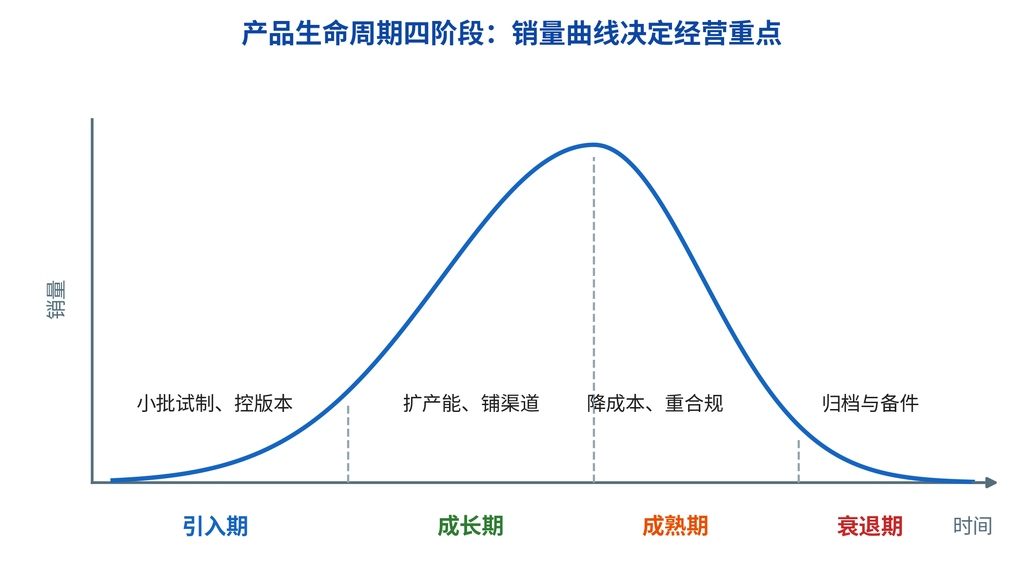

- **是什么**：市场生命周期（销量与利润）与数据生命周期（版本与归档）是两套时钟
- **为什么**：两者节奏不同步——产品还在成熟期，图纸可能已改到 C 版；产品退市，图纸还要留档
- **怎么判断**：看阶段切换信号——销量增速、毛利、竞品数量、替代技术
- 各阶段动作：引入控版本、成长管配置、成熟重成本与合规、衰退做归档；数据侧：需求→设计→工艺→制造→服务→归档

## BOM 家族：EBOM、MBOM、SBOM 与配置 BOM

| 类型 | 生成者 | 组织逻辑 | 主要用途 |
| --- | --- | --- | --- |
| EBOM | 设计部门 | 按产品功能结构 | 设计、采购、成本估算 |
| MBOM | 工艺部门 | 按装配顺序与工位 | 领料、工序、装配 |
| SBOM | 销售、服务 | 按客户配置与备件 | 报价、订单配置、售后 |
| 配置 BOM | 产品平台 | 全配置超集（150%） | 按特征裁剪订单 BOM |

- 名称对应：EBOM 设计 BOM、MBOM 制造 BOM、SBOM 销售与服务 BOM
- 转换要点：EBOM→MBOM 补**工艺路线、虚拟件（油漆、包装）、替代料、损耗率**
- 配置 BOM 是“超集”：把全部可选件收进来，用配置特征与规则裁剪成订单 BOM
- 示例：3 种功率 × 2 种安装方式＝6 个变型；150% BOM 收全部选项，订单只取一套
- BOM 颗粒度：采购件到最小采购单元，自制件到工序可分的层级
- 转换规则要成文：增件、并件、拆件、替代四类规则各一张表
- 一致性：各视图共用一套物料编码；版本与生效日期必须对齐
- 常见错误：拿 EBOM 直接采购（漏辅料与损耗）、MBOM 与工位不对应

## 图文档管理与版本控制

- 五类对象：3D 模型、2D 工程图、技术规范与计算书、软件／固件、工艺文件
- 三个概念：**版本**（改几次）、**版次**（发布几次）、**基线**（冻结的一套文件）
- 状态机：工作中→审批中→已发布→已归档；已发布只读，修改必须升版
- 权限随状态走：发布后作者也只剩只读，改图必须走新版本
- 检入／检出：一次只允许一人修改，避免“最终版-最终版-改”
- 有效性：按日期、批次或序号生效；旧版不能一删了之，要能回答当时用哪版
- 命名：图号唯一，文件名不带“最终版”；材料、重量等属性放系统字段

| 状态 | 能否修改 | 谁可见 | 典型操作 |
| --- | --- | --- | --- |
| 工作中 | 可改 | 作者与项目组 | 检入、检出 |
| 审批中 | 只读 | 审批人 | 会签、退回 |
| 已发布 | 只读 | 全公司按权限 | 发放、引用 |
| 已归档 | 只读 | 审计与档案 | 查询、留证 |

## 变更管理：ECR、ECO 与 ECN

| 单据 | 回答的问题 | 关键内容 |
| --- | --- | --- |
| ECR | 为什么要改 | 问题、理由、初步影响 |
| ECO | 批准怎么改 | 方案、范围、生效时点 |
| ECN | 通知谁执行 | 受影响物料、工单、日期 |

- 全称：ECR 工程变更申请、ECO 工程变更指令、ECN 工程变更通知
- 流程：提出→影响分析→评审批准→执行→验证→关闭；每一步留痕
- 影响分析五问：哪些零件、多少在制、多少库存、多少已售、是否影响认证
- 分类：设计／工艺／物料变更；紧急／常规；不同类别走不同审批层级
- 变更委员会：设计、工艺、制造、质量、采购必须同台
- 生效时点四选一：立即、按批次、按日期、按序号；必须写进单据
- 四个必须：变更单号唯一、旧料处理方案、验证记录回写、关闭条件明确
- 典型事故：只改 PLM 不改 ERP → 采购按旧 BOM 下单 → 新旧料混用

## 项目管理与研发流程 P0–P6

| 阶段 | 名称 | 关键交付物 | 退出判据 |
| --- | --- | --- | --- |
| P0 | 概念与定义 | 商业论证、需求草案 | 立项批准 |
| P1–P3 | 立项、设计、验证 | 计划、样机、测试报告 | 设计冻结 |
| P4–P5 | 上市与运营 | 上市计划、量产爬坡 | 达产达标 |
| P6 | 退市 | 退市方案、服务终止 | 库存与服务清理 |

- 产品开发流程 P0–P6 覆盖“创意→退市”；P0 定做不做，P1–P3 定怎么做，P4–P6 定怎么卖、怎么退
- 阶段门（Gate）三问：交付物齐吗、指标达标吗、资源继续投吗
- 里程碑设置：每个 Gate 至少一个可验证的量化指标
- 三重约束：范围、进度、资源；任何一项变更，另两项必须重算
- 资源冲突时先保关键路径，非关键任务可并行、外包或推迟
- 甘特图看**关键路径与资源冲突**，不只看颜色条
- 项目管理的产出不是文档，而是“可决策的节点”

## 研发到量产：漏斗与阶段门

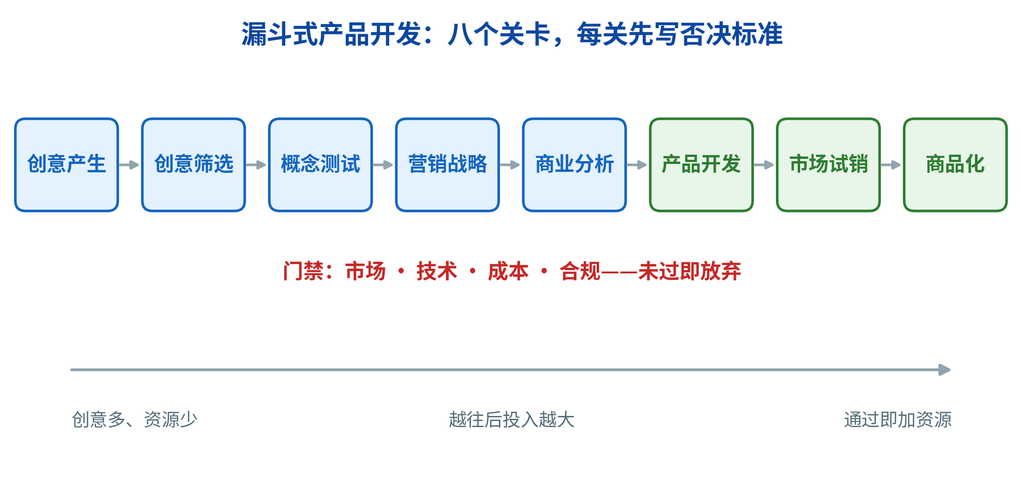

- 漏斗回答“做不做”：创意多、资源少，逐层筛选
- 八关：创意→筛选→概念测试→营销战略→商业分析→开发→试销→商品化
- 每关先写否决标准：市场、技术、成本、合规；标准前置，避免事后拍板
- 通过即加资源，否决即放弃，不允许“挂着”占用预算
- 漏斗是决策逻辑，P0–P6 是流程骨架

## 甘特图：看关键路径与资源冲突

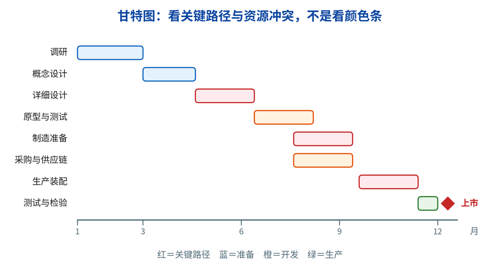

- **是什么**：任务、时间轴、里程碑三件套；甘特图回答“什么时候做、谁先做”
- **关键路径**：最长的那条链决定最短工期——压缩非关键任务不会缩短项目
- **资源冲突**：两个任务同期并行、抢同一批人，就得调序或加人
- **怎么判断**：问“哪几项延迟会推迟上市”——答得出的才是关键路径

## 协同开发：并行工程与跨组织

- 串行：设计→工艺→试制依次交接，问题到试制才暴露，返工最贵
- **并行工程（CE）**：下游早期介入，把可制造性、可装配性、可维护性、可测试性前置
- 三个层次：部门内（设计—工艺）、企业内（＋制造、采购、质量）、跨企业（供应商、客户）
- 平台四要素：统一数据源、权限与保密、工作流与评审、变更通知
- 跨组织难点：知识产权、数据交换标准（STEP 产品模型数据交换标准、XML 可扩展标记语言）、时区与语言
- 指标：开发周期、设计返工次数、变更响应时间
- 示例：设计 16 周、工艺 12 周、试制 12 周，串行 40 周；工艺第 8 周介入、试制在工艺第 6 周介入，则 $16+(12-8)+(12-6)=26$ 周，缩短 35%

## 需求管理与系统工程

- 需求层级：客户需求→系统需求→子系统／部件需求→工艺与验证需求
- 每条需求五要素：唯一 ID、来源、优先级、验证方法、状态
- 追溯矩阵：需求→设计→验证→变更四类对象对齐；断链就是隐患
- 示例：240 条需求，216 条已验证，覆盖率 $R=216/240=90\%$；18 条无设计追溯（7.5%），6 条无验证（2.5%）
- MBSE（基于模型的系统工程）：用 SysML（系统建模语言）模型承载需求、结构、行为，替代纯文档传递
- 变更影响：需求变→设计变→BOM 变→工艺变→验证重做
- 判据：任一需求能答出“谁提出、哪版设计满足、哪次试验证明”

## 数字化设计与仿真：CAD／CAE／CAM

- CAD：三维建模、装配、工程图；模型与图纸是 PLM 的数据源头
- CAE：结构、流体、热、运动、电磁仿真；在设计阶段验证性能，减少实物试验
- CAM：由模型生成刀路与 NC 程序，经后处理驱动机床；与工艺路线、工装关联
- 三条数据链：模型→仿真→试验（V&V）；模型→工艺→NC；模型→BOM→ERP
- 仿真数据管理：模型、边界条件、结果、报告必须与版本绑定，否则结论不可复现
- 数字样机（DMU）：干涉检查、装配顺序、维修可达性
- 判据：仿真报告能否回答“哪版模型、什么边界条件、谁批准”

| 工具 | 主要输出 | 在 PLM 的挂接对象 |
| --- | --- | --- |
| CAD | 模型、装配、工程图 | 零件与文档 |
| CAE | 网格、结果、报告 | 仿真模型与版本 |
| CAM | 刀路、NC 程序 | 工艺路线与工装 |

## 工艺设计 CAPP 与 PLM

- CAPP：计算机辅助工艺过程设计；输出工艺路线、工序卡、工装清单、检验计划
- 三类：检索式（查相似工艺）、派生式（按零件族修改）、创成式（按规则生成）
- 工艺是产品数据的一部分：工艺版本随设计版本走，MBOM 在工艺设计中定型
- 三处衔接：PLM（工艺文件与版本）、ERP（路线、工时、工作中心）、MES（作业指导书、参数）
- 五个输入：图纸、EBOM、设备能力、工时定额、质量要求
- 常见断点：工艺留在 Excel／Word 里，ERP 手工录路线，MES 再抄一遍
- 判据：工艺变更后，ERP 路线与 MES 指导书是否同一版本

## PLM 与 ERP 的集成：三张清单

| 对象 | PLM 职责 | ERP 职责 | 一致性判据 |
| --- | --- | --- | --- |
| 物料主数据 | 申请、属性、图号关联 | 按规则建码、采购与库存参数 | 一物一码、单位一致 |
| BOM | EBOM／MBOM、版本 | 接收、按版本展开 | 层级、用量、生效日 |
| 工艺路线 | 路线、工序、工时 | 工作中心、费率 | 工序号与工时一致 |

- 方向：PLM→ERP 为主；ERP 回传库存、成本、采购可得性
- 时序：设计发布→ERP 建物料→BOM／路线生效→MRP 运算→采购生产
- 集成方式：接口表、中间件、ESB（企业服务总线）、API（应用程序接口）；避免人工 Excel 导入
- 典型错误：一物多码、BOM 层级错、虚拟件被采购、单位换算错
- 变更单：PLM 发起、ERP 执行并归集成本，用同一单号贯穿
- 接口对账：每日比对物料数、BOM 行数、路线工序数
- 判据：ERP 里任一物料能反查到 PLM 的图号与版本

## PLM 与 MES 的集成：图纸与工艺下发

- 下发内容：图纸／模型（只读）、作业指导书、工艺参数、检验标准、用料清单
- 触发：工单下达时按“物料＋版本＋生效日期”绑定，而不是人工找文件
- 现场：工位终端扫码调阅；版本不符则无法开工（防错）
- 回传：实际工时、设备参数、质量结果、异常，由 MES 回流 PLM 与 ERP
- 变更切换：旧版工单用完、新版按批次／日期生效；首件必检
- 风险：图纸已改、工单仍旧版；现场用 U 盘拷“最新版”
- 追溯：工单、图纸、工艺、批次四者绑定，扫码即得全套

| 下发对象 | 来源 | 接收方式 |
| --- | --- | --- |
| 图纸与模型 | PLM | 工位终端只读调阅 |
| 作业指导书 | PLM/CAPP | 工位屏、电子看板 |
| 工艺参数 | CAPP/PLM | 设备接口、扫码下发 |
| 检验标准 | PLM/QMS | 检验终端 |

## 产品数据安全与权限

- 数据分级：公开、内部、秘密、机密；分级决定审批层级与外发方式
- 权限模型：RBAC（基于角色的访问控制）＋项目域＋密级，三者取交集；默认最小权限
- 知必所需：供应商只看相关零件，只读、带水印、限时
- 控制手段：访问控制、加密存储、外发审批、屏幕水印、下载审计、离线授权
- 审计：谁在何时下载／打印／外发了哪份文件，日志不可改
- 离职转岗：账号即时停用、权限回收、文件交接
- 平衡：权限过严→员工绕开系统用微信传图，反而更不安全
- 判据：10 分钟内列出某机密图纸的全部访问记录

## PLM 选型与实施

- 选型六维：功能覆盖、行业适配、集成能力、TCO、供应商服务、扩展性
- 权重示例（取前五项）：功能 30%、集成 25%、行业 20%、TCO 15%、服务 10%；五项按 1–5 分打分，加权总分 $S=\sum_{i=1}^{5}w_i s_i$（$w_i$ 为权重、$s_i$ 为评分）
- A 与 B 仅差 0.10 分：进入演示与参考客户考察，不靠分数定标
- 实施五阶段：规划诊断→选型→试点→推广→运维
- 试点指标：版本错误率、变更周期、图纸查找时间
- 失败五因：当网盘用、主数据不治、流程不改、一把手不参与、贪大求全
- 合同要点：数据归属、接口责任、验收标准、退出机制

| 供应商 | 加权得分 | 关键短板 |
| --- | --- | --- |
| A | 4.15 | 集成能力一般 |
| B | 4.05 | 行业案例少 |
| C | 3.70 | 功能覆盖弱 |

## 数字孪生与产品数字主线

- 数字孪生：物理实体的虚拟映射，模型＋实时数据＋双向连接，用于监控、预测、优化
- 三要素：模型（几何／物理／行为）、数据（传感器／工单／质量）、服务（仿真／预警／优化）
- 产品孪生与产线孪生：前者管“产品怎么用”，后者管“怎么造”
- 数字主线：贯穿需求→设计→工艺→制造→服务的受控数据链，强调连得上、追得回
- 关系：主线是“线”，孪生是“点／体”；没有主线，孪生只是演示动画
- PLM 提供模型与 BOM，MES 提供过程，IoT 提供状态
- 成熟度：模型可视化→数据回传→闭环优化，逐级投入

**结论：主线连着数据，孪生用着模型；没有实时数据的孪生只是动画。**

## 制造业数据主线：从需求到退役

| 环节 | 产生数据 | 权威系统 | 下游用途 |
| --- | --- | --- | --- |
| 需求 | 需求条目、验收准则 | PLM | 设计输入、验证 |
| 设计 | 模型、图纸、EBOM | PLM | 工艺、采购 |
| 工艺 | 路线、MBOM、作业书 | PLM/CAPP | 生产、检验 |
| 制造 | 工单、批次、实绩 | MES | 追溯、成本 |
| 服务 | 故障、备件、升级 | CRM/PLM | 改进、退市 |

- 主线三要素：唯一标识（件号／序列号）、版本关联、双向追溯
- 断点：手工转录、Excel 传递、邮件发图、系统间无接口
- 断点修复：接口自动带版本，交接双方签收
- 主线不是“把所有数据存一处”，而是“知道数据在哪、哪版、谁负责”
- 主线归属：每个环节指定数据负责人，交接要有签收
- 价值：变更影响分析快、召回范围准、问题定位短
- 判据：任取一台产品，10 分钟内答出“哪版图纸、哪版 BOM、哪道工艺、哪批来料”

## 系统蓝图：ERP／MES／PLM 三位一体

> 上一页看数据怎么连，这一页看三个系统怎么分工。

| 系统 | 管理对象 | 主数据 |
| --- | --- | --- |
| PLM | 产品定义 | BOM、图文档、工艺 |
| ERP | 资源与交易 | 物料、库存、价格、供应商、成本 |
| MES | 执行与实绩 | 工单、批次、设备、质量 |

- 三条主链：PLM→ERP（BOM、物料、路线）、ERP→MES（工单、计划）、MES→PLM（实绩、质量、工艺反馈）
- 三个闭环：设计闭环（变更验证）、执行闭环（计划→实绩）、质量闭环（问题→改进）
- 主数据归属：一处维护、多处引用；下游不另建主数据
- 集成总线：ESB、API、中间表；接口要有日志、重传、对账
- 组织保障：主数据责任人、变更委员会、接口责任人
- 接口清单：每个接口写明触发事件、频率、责任人与回滚方案
- 反模式：三套系统各建一套物料码，靠 Excel 对账

## 案例：一次设计变更的系统旅程

| 时点 | 系统动作 | 责任方 | 输出 |
| --- | --- | --- | --- |
| D0 | PLM 建 ECR | 设计 | ECR-2026-014 |
| D1–D2 | 三系统影响分析 | 设计、工艺、计划 | 影响清单 |
| D3–D5 | 评审、发布 ECO／ECN | 变更委员会 | 新版图与 BOM |
| D6–D10 | ERP 改料、MES 切工单 | 采购、工艺、车间 | 新工单、作业书 |
| D15 | 首件检验与验证 | 质量 | 验证报告 |

- 对象：R-200 减速器轴承 6208→6209，2 件／台；影响 3 个零件、2 道工序、1 套工装
- 库存 1,200 件、日耗 40 件，可用天数 $D=1200/40=30$ 天；新件提前期 45 天，D0 才下单则第 30–45 天缺口 $(45-30)\times40=600$ 件
- 在制 80 台需返工、已售 300 台需服务评估，影响范围写进 ECR
- 只改 PLM 的后果：采购按旧 BOM 下单、车间按旧图加工、售后备件错发
- 旧料处理三选一：用完、代用、报废；必须与采购、计划共同签字
- 旧料 1,200 件按 38 元／件计，全额报废即损失 45,600 元，须在 ECO 中定方案
- 闭环标志：变更关闭时，图、料、单、检四件事都能追到同一单号

## 集成案例：四流在一条 ECN 上的流转

- **信息流**：ECN 单号贯穿 PLM（版本）→ ERP（物料与工艺）→ MES（工单与作业指导书）
- **物料流**：旧料冻结（WMS）→ 新料采购（ERP）→ 线边切换（MES）→ 呆滞处理（WMS）
- **资金流**：变更成本（报废、返工、加急）归集到 ERP 的成本中心
- **质量流**：变更后首件检验 + SPC 监控 + 验证报告，回流到 PLM 的变更验证记录
- 四流共用**一个变更单号**，才谈得上“端到端可追溯”
- 判据：任取一台产品，能否在 10 分钟内答出“它用的是哪版图纸、哪版 BOM、哪道工艺”

## 伦理（一）：数据采集与员工隐私

- 场景：MES 记录“张三 14:32 在 3 号工位扫码，用时 47 s，参数超差 1 次”
- 这类数据**能精确到人**：可以做质量分析，也可以做绩效排名、考勤、甚至惩罚依据
- 四条准则（需同时满足）：
  - **目的正当**：为质量追溯与过程改进而采集
  - **范围最小**：只采与质量相关的字段，不采集无关行为
  - **留存有期**：明确保存期限，到期删除或匿名化
  - **使用受限**：明确谁可以查、查什么、留审计日志
- 设计做法：个人标识与过程数据分离、统计用聚合数据、异常分析先匿名化
- 反面后果：员工对抗采集 → 数据造假或漏扫 → 追溯失效，质量损失反而更大

## 伦理（二）：追溯与监控的边界

- 追溯的两类用途：
  - **质量闭环**：查原因、定范围、防再发（正当）
  - **个人问责**：找“谁背锅”（越界风险高）
- 边界判据：追溯数据用于**改进系统**（工艺、防错、培训）＝正当；用于替代管理与培训＝越界
- 制度设计三条：
  - 质量责任与个人绩效**分离**：先改进、后问责，且问责基于制度而非数据便利
  - **举报保护**：主动报告问题的人不被追责，否则坏消息会被隐瞒
  - **数据用途事先声明**：采集前告知用途，变更用途需重新告知
- 与 8D 的接口：D7“预防再发”改的是系统，不是换人——这是质量伦理的底线

## PLM 复习要点

| 对比项 | 一句话区别 | 常见考法 |
| --- | --- | --- |
| PLM／PDM | PLM 是全集，PDM 是子集 | 简述区别与判据 |
| EBOM／MBOM | 功能结构／装配顺序 | 转换要补什么 |
| ECR／ECO／ECN | 要不要改／怎么改／通知 | 流程排序 |
| 孪生／主线 | 模型怎么用／数据怎么连 | 概念辨析 |

- 三条流程：图文档发布、ECR→ECO→ECN、PLM→ERP→MES 集成
- 五层组成：标准→工具→核心→应用→行业方案
- 三个判据：单一数据源、版本有效性、端到端追溯
- 三个关键标识：物料号、变更单号、工单号，能把整条链串起来
- 易错点：把 PLM 当网盘、EBOM 直接采购、变更只改 PLM、权限一放到底
- 必会计算：BOM 展开、加权选型评分、变更影响范围
- 答题模板：先定义，再画流程，再给判据，最后给反例

## 推导留给 AI：PLM 与系统集成（汇总）

- 用一句话区分 PLM 与 PDM，并给出三个可观察的判据
- 给定一个产品的 EBOM，写出转换为 MBOM 需要补充的四类信息
- 一条 ECN 在 PLM→ERP→MES 中若不同步，列出三种典型故障及其发现时点
- 为 MES 追溯数据设计一份“使用边界”清单（谁可查、查什么、留多久、如何审计）

## 本部分小结：产品定义与系统集成

- PLM 是产品定义的权威源，既管数据也管过程
- 四根支柱：单一数据源、BOM 家族、版本控制、变更管理
- 集成不是接口，而是“同一份数据在正确的时间到正确的系统”
- 三条链路：PLM→ERP（定义）、ERP→MES（执行）、MES→PLM（反馈）
- 数字主线让设计—制造—服务可追溯，数字孪生让状态—预测可计算
- 一条底线：数据安全与权限，决定协同能走多远
- 下一部分：用例题检验——MRP 展开、追溯范围、系统选型

# 第五部分 · 例题、讨论与 AI 提问

- 真题：本讲相关题分布与给分点（MES 目标、ERP 模块）
- 计算例题：MRP 三层展开与批量取整、低层码与计划订单
- 例题：追溯范围与召回成本；给业务场景选系统（8 个场景）
- 课堂讨论：信息孤岛背后的部门博弈；追溯数据能不能用来考核
- **承上**：上一部分把产品定义收在 PLM 与三条集成链路上；本部分把四个内容块收进例题、讨论与自测——先算准，再辩清。

## 历年真题：本讲相关题分布

> 例题之前先看分布：本讲直接相关的分值只有两处，其余按延伸题准备。
- 六卷指 2020／2021／2022 三届 A／B 卷，结构一致：单选 30＋简答 30＋论述 30＋计算 10
- 本讲直接分值集中在两处：MES 目标单选 3 分（六卷全有）＋系统组成简答 5 分（五卷出现）
- ERP 模块、PLM、MRP 展开均未单独命题；六卷计算题固定为静态投资回收期

| 考点 | 题型·分值 | 出现卷次 |
| --- | --- | --- |
| MES 三大目标 | 单选 3 分（第 7 或 8 题） | 六卷全有 |
| 系统五个组成 | 简答 5 分（第二大题） | 五卷有，2022A 未出 |
| ERP 核心模块 | 未单独命题 | — |
| PLM 与 BOM | 未单独命题 | — |
| MRP 展开计算 | 未单独命题 | — |

- 六卷合计直接分值 43 分，平均每卷 7.2 分；简答 5 分是性价比最高的一题
- 复习策略：单选送分必拿，简答按“名称＋功能”成对准备，模块与集成按延伸题准备

## 真题：MES 目标与系统组成给分点

**单选（六卷全有，3 分）** 下列不属于 MES 目标的是（ ）A 防错 B 改善 C 追溯 D 销售 → 答案 **D**，销售归 CRM

**简答（5 分，五卷出现）** 列举智能制造系统的 5 个组成（如 APS），并简要介绍其功能

| 采分点 | 分值 | 阅卷判据 |
| --- | --- | --- |
| 名称写对 | 2.5 分 | 五个名称各 0.5 分，写全即可 |
| 功能成对 | 2.5 分 | 每个功能 0.5 分，必须与名称对应 |
| 总起句 | 加分项 | 先写“由……组成”，再逐条展开 |
| 常见扣分 | — | APS 只写“高级计划”却描述成执行；只写名称 |

- 功能关键词：ERP 管资源与账、MES 管执行、PLM 管产品定义、APS 管排程、CRM 管客户、WMS 管库位
- 答题顺序建议：ERP→MES→PLM→APS→CRM，五个写满即可，不必多写
- 易错：把 MES 的“防错、改善、追溯”当成系统组成来答，那是目标不是组成

## 真题：ERP 核心模块与集成简答

- 六卷未单独命题 ERP 模块；但“五个组成”题的同一模板可直接套用，答五个模块即可
- ERP 的标准模块有十个，考场上按“财务、管理、生产、供应链、订单”五类各写一句最稳

| 模块 | 一句话功能 | 主要集成对象 |
| --- | --- | --- |
| 财务会计 | 总账、应收应付、固定资产、现金 | 采购、销售、生产实时过账 |
| 管理会计 | 预算、成本核算与控制 | 取 MES 工时与物料消耗 |
| 生产 | BOM、工单、产能评估、进度监控 | 向 MES 下工单、收报工 |
| 供应链 | 采购、库存、供应商评估 | 与 WMS 对接库位与批次 |
| 订单处理 | 订单录入、信用评估、发货 | 与 CRM 对接客户与商机 |

- 集成答题只写“数据流向”：PLM 送 BOM 与工艺，ERP 送工单，MES 回报工与在制，WMS 报库存
- 判据一句：ERP 是“计划与账”的主库，不是车间的实时系统
- 常见扣分：把集成答成“接口很多、数据共享”，没有说清谁给谁、给什么、多久一次

## 计算例题：MRP 三层展开与批量取整 —— 题干与思路

练“毛需求逐层下推、批量取整、按提前期倒排”的完整展开能力，对应 ERP 内核 MRP 的四步。

**已知**：产品 M 第 9 周需 500 台；BOM 为 1 台 M＝2 件 N＋1 件 O，1 件 N＝4 件 P；库存 M 80 台、N 120 件、O 60 件、P 300 件；批量规则 N 300 件、P 1,000 件，M、O 直接批量；提前期 M 1 周、N 2 周、O 1 周、P 2 周。

**求**：① M、N、O、P 的毛需求；② 各物料的净需求；③ 批量取整后的计划订单量与下达周。

**公式**：净需求＝毛需求−库存；计划订单量＝净需求按批量向上取整后的整批数×批量，直接批量时等于净需求；子件毛需求＝父项计划订单量×用量；下达周＝需求周−提前期。

**路线**：① 顶层 M 减库存得净需求 → ② 按 M 计划订单展开 N、O，减库存、取整 → ③ 按 N 计划订单展开 P，再减库存、取整 → ④ 逐层倒排下达周。

## 计算例题：MRP 三层展开与批量取整 —— 分步解答

**第 1 步 M**：500−80＝420 台，直接批量订 420 台，提前期 1 周，第 8 周下达。

**第 2 步 N、O 部件**：N 毛需求 2×420＝840 件，净 840−120＝720 件，720÷300 需 3 批，订 900 件，第 6 周下达；O 毛需求 1×420＝420 件，净 420−60＝360 件，订 360 件，第 7 周下达。

**第 3 步 P 零件**：毛需求按 N 的计划订单展开，4×900＝3,600 件；净 3,600−300＝3,300 件，3,300÷1,000 需 4 批，订 4,000 件，第 4 周下达。

**第 4 步 汇总**：四个物料的毛需求、净需求与计划订单见下表，下达周按“需求周−提前期”倒排。

| 物料 | 毛需求 | 净需求 | 计划订单 |
| --- | --- | --- | --- |
| M 整机 | 500 台 | 420 台 | 420 台（第 8 周） |
| N 部件 | 840 件 | 720 件 | 900 件（第 6 周） |
| O 部件 | 420 件 | 360 件 | 360 件（第 7 周） |
| P 零件 | 3,600 件 | 3,300 件 | 4,000 件（第 4 周） |

**判读**：净需求、批量取整、倒排三者的顺序不能颠倒。

**易错点／验算**：按 N 净需求 720 展开，P 只得 2,880 件，少 720 件；N 多订的 180 件乘 4 正好是这 720 件。

## 计算例题：低层码与计划订单 —— 题干与思路

练“同一物料跨两层出现时只汇总一次”的能力：低层码决定先算哪一层、在哪里下单。

**已知**：1 台 G 用 1 件 H、2 件 K，1 件 H 用 3 件 K；G 第 10 周需 200 台；H 库存 50 件、K 库存 100 件；K 批量 400 件，G、H 直接批量；本例不计提前期，按同一需求周汇总。

**求**：① G、H、K 的低层码；② 各物料的毛需求与净需求；③ K 的计划订单量，并算出按层分开算会多订多少件。

**公式**：低层码＝物料在产品结构中出现的最深层次，顶层记 0；K 的毛需求＝2×G 计划订单＋3×H 计划订单；净需求＝毛需求−库存；计划订单量＝净需求按批量向上取整后的整批数×批量。

**路线**：① 画两层结构、定各物料低层码 → ② 按低层码从小到大先算 G、H → ③ 到 K 的最深层一次汇总两路毛需求 → ④ 减库存、取整，再与按层分开算的结果对比。

## 计算例题：低层码与计划订单 —— 分步解答

**第 1 步 定低层码**：G 为 0，H 为 1，K 取最深记 2。

**第 2 步 先算上层**：G 毛需求 200 台、无库存，净需求 200 台，直接批量订 200 台；H 毛需求 1×200＝200 件，净 200−50＝150 件，订 150 件。

**第 3 步 K 一次汇总**：毛需求 2×200＋3×150＝400＋450＝850 件；净 850−100＝750 件；750÷400 需 2 批，订 800 件。

**第 4 步 与按层分算对比**：第 1 层 K 净 300 件订 400 件，第 2 层净 450 件订 800 件，合计 1,200 件，比一次汇总的 800 件多订 400 件。

| 物料 | 低层码 | 毛需求 | 净需求 | 计划订单 |
| --- | --- | --- | --- | --- |
| G 整机 | 0 | 200 台 | 200 台 | 200 台 |
| H 部件 | 1 | 200 件 | 150 件 | 150 件 |
| K 齿轮 | 2 | 850 件 | 750 件 | 800 件 |

**判读**：低层码让同一物料只在最深层汇总一次，不漏算也不重复采购。

**易错点／验算**：K 的毛需求两路要相加，400＋450＝850 件；1,200−800＝400 件正是按层分算多订的代价，库存 100 件只抵扣一次。

## 例题 1：追溯范围与召回成本 —— 题干与思路

练“把追溯颗粒度换算成召回成本”的能力：追溯做得越细，召回范围越小、省下的钱越多。

**已知**：某工单装配 2,000 台，关键件分三个批次：A 批次 700 台、B 批次 900 台、C 批次 400 台；现确认 B 批次存在缺陷，不良率 6%，单台返工成本 150 元。

**求**：① 全量召回与精确追溯召回的返工成本（万元，保留一位小数）；② 精确追溯节省多少万元、节省率百分之几；③ 抽检 50 台预期发现几台不良；④ 先做 100% 检测再返工，返工量降到多少台。

**公式**：召回成本＝召回台数×单台返工成本；节省额＝全量成本−追溯成本；节省率＝节省额÷全量成本；抽检期望不良数＝抽检台数×不良率；100% 检测后返工量＝该批次台数×不良率。

**路线**：① 按全工单 2,000 台算全量召回成本 → ② 只按 B 批次 900 台算追溯召回成本 → ③ 相减得节省额与节省率 → ④ 用 6% 算抽检期望与筛选后的返工量。

## 例题 1：追溯范围与召回成本 —— 分步解答

**第 1 步 全量召回**：2,000 台×150 元/台＝300,000 元＝30.0 万元。

**第 2 步 精确追溯**：只召回 B 批次 900 台，900×150＝135,000 元＝13.5 万元。

**第 3 步 节省**：30.0−13.5＝16.5 万元；节省率 16.5÷30.0＝55%。

**第 4 步 抽检与筛选**：抽检 50 台×6%＝3 台，抽样不能替代全数追溯；若 100% 检测筛选，真正要返工的只有 900×6%＝54 台。

| 项目 | 计算 | 结果 | 单位 |
| --- | --- | --- | --- |
| 全量召回 | 2,000 台 × 150 元/台 | 30.0 | 万元 |
| 精确追溯召回 | 900 台 × 150 元/台 | 13.5 | 万元 |
| 节省 | 30.0 － 13.5 | 16.5（55%） | 万元 |
| 抽检期望 | 抽 50 台 × 6% | 3 台 | 台 |

**判读**：颗粒度从工单细到批次，召回成本从 30.0 万元降到 13.5 万元。

**易错点／验算**：召回台数别把 A、C 批次算进去；验算 30.0×55%＝16.5 万元。

## 例题 2：给业务场景选系统 —— 题干与思路

练“按回答什么问题选系统”的能力：先判断问题该由哪套系统回答，跨领域的要答“两套系统＋集成”。

**已知**：八个业务场景——① 客户询价与信用额度审核；② 确认某型号用哪一版图纸；③ 计算第 8 周需要多少 D 件；④ 设备故障后重新安排工序；⑤ 查某托盘的库位与批次；⑥ 客户投诉批次反查；⑦ 工程变更影响哪些在制工单；⑧ 交付承诺与产能平衡。

**求**：逐个指出应选系统或系统组合，并用一句话说明判断理由；指出哪几个场景不能只选一套系统。

**判据**：问产品→PLM；问资源与钱→ERP；问做没做→MES；问库位→WMS；问客户→CRM；问排程→APS；跨两个领域时答“主导系统＋协同系统”。

**路线**：① 把场景翻成一句“要回答什么问题” → ② 按判据落到主导系统 → ③ 跨领域的补上协同系统 → ④ 用数据流向复核答案是否说得通。

## 例题 2：给业务场景选系统 —— 分步解答

**第 1 步 落主导系统**：客户与信用归 CRM，图纸版本归 PLM，物料需求展开归 ERP 的 MRP，工序重排归 MES，库位批次归 WMS，投诉批次归 MES，交期与产能归 APS。

**第 2 步 补协同系统**：询价与信用额度审核＝CRM＋ERP 财务，工程变更影响在制工单＝PLM＋MES。

| 业务场景 | 应选系统 | 判断理由 |
| --- | --- | --- |
| 询价与信用审核 | CRM（＋ERP 财务） | 管客户与信用，订单结算在 ERP |
| 查图纸版本 | PLM | 产品定义的权威源在 PLM |
| 算第 8 周 D 件 | ERP（MRP） | 物料需求展开是 MRP 的核心 |
| 故障后重排工序 | MES（或 APS） | 执行层实时调度 |
| 查库位与批次 | WMS | 物料流的库位主责在 WMS |
| 投诉批次反查 | MES | 追溯链在执行层 |
| 变更影响在制 | PLM ＋ MES | 变更源在 PLM，在制在 MES |
| 交期与产能平衡 | APS | 有限产能下的排程 |

**判读**：八题里六题单选、两题双系统；双系统题考的是谁给谁、给什么数据。

**易错点／验算**：别把跨系统场景都答成 ERP；工程变更源头在 PLM，在制状态在 MES。

## 简答模板：ERP／MES／PLM 各答三段

> 四道例题落在算数与选系统上；这一页把 ERP／MES／PLM 的回答收成可套用的三段式。
- 三段式：第一段定义（是什么），第二段要素（管什么），第三段边界（与谁集成、给什么数据）

| 系统 | 第一段 定义 | 第二段 要素 | 第三段 边界 |
| --- | --- | --- | --- |
| ERP | 一个数据库管三类资源 | 财务、生产、供应链；MRP 是内核 | 收 MES 报工与 PLM 的 BOM |
| MES | ERP 与设备之间的执行层 | 防错、改善、追溯；工单与采集 | 接 ERP 工单，向 ERP 回写 |
| PLM | 产品定义的权威源 | PDM、BOM、工艺、ECN | 向 ERP 送 MBOM，向 MES 送工艺 |

- 万能句式：“X 是……的系统，主责……流，向 A 提供……，从 B 接收……”
- 5 分题按段给分：定义 1 分、要素 2 分、边界 2 分，三句话就能凑满
- 收尾一句：ERP 管资源、MES 管执行、PLM 管产品定义——三者边界由“回答什么问题”决定
- 常见扣分：只背模块名不写边界；把 PLM 说成“图纸管理系统”，漏掉 BOM 与 ECN

## 课堂讨论：信息孤岛背后的部门博弈

**现象**：同一批库存，财务按月末结账口径、生产按当班口径、采购按在途口径，三个数字都对，但永远对不上。

- 讨论 1：三个口径哪个应该做主？谁有权决定？
- 讨论 2：如果统一口径会让某个部门“数字变难看”，改革推得动吗？
- 讨论 3：主数据治理应该由谁负责——IT、财务，还是业务部门？

> 信息孤岛往往不是技术问题，而是**责任与权力的分配问题**。

## 课堂讨论：追溯数据能不能用来考核员工

**场景**：MES 能查到每个工位、每个人的操作记录与不良记录。

- 正方：数据客观，为什么不能用于绩效？
- 反方：一旦用于惩罚，员工会隐瞒与造假，数据质量崩塌
- 折中：分层使用——过程数据用于改进，聚合数据用于绩效，个人数据限定用途并审计
- 判据回到四条准则：**目的正当、范围最小、留存有期、使用受限**

## 开放问题：集成项目为什么失败

- **主数据脏**：物料一物多码、BOM 版本混乱 → 接口再多也白搭
- **流程照搬**：把手工流程原样搬进系统，只是把错误变快
- **一把手缺位**：跨部门口径没人拍板，IT 部门推不动业务
- **范围失控**：一期想上全模块，结果每个模块都半成品
- 讨论：如果要你给一家年产值 5 亿元的企业写“系统集成路线图”，第一年做什么？

## 课堂讨论：上 ERP 前要不要先做流程优化

**情境** 某厂准备上 ERP，暴露三个老问题：一物多码、审批七级、台账靠手工。

- 正方：流程不改就上线＝把错误流程固化，日后改系统代价更高
- 反方：不上系统流程永远说不清；系统自带最佳实践，先标准化
- 折中：先做**减法**（取消、合并），再**固化**（标准化、上系统），最后**优化**
- 边界：优化不是推倒重来，先砍“不产生价值的审批与等待”
- 判据一：跨部门扯皮的流程，先定责任与口径，再上系统
- 判据二：一物多码、BOM 版本这类主数据，必须在上线前治理
- 判据三：在制不清、齐套不明属“系统才看得见”，可以先上再改
- 一句判断：系统是锦上添花不是雪中送炭，ERP 不替代基础管理
- 讨论：预算只够先做一件事，你先做哪件？

## 课堂讨论：MES 数据没人用问题在哪

**现象** MES 上线一年，看板挂在车间，班组长仍用纸质报表；数据只在月底盘点时被想起。

- 四问定位：谁看（角色）→看什么（指标）→看了做什么（动作）→做完谁验证（闭环）
- 病灶一 无主：指标不进班组考核，数据好坏与谁都不相关
- 病灶二 不信：采集口径与手工账对不上，一次对不上就再没人看
- 病灶三 无用：看了也不能停线、不能调人，数据不产生动作
- 病灶四 无闭环：异常报上去，处理结果不回填，下次照旧
- 判据：一条数据若不能在 24 小时内触发一个动作，就不该采
- 处方：先选三个指标（达成率、直通率、停机时长），配三个动作与一个日会
- 讨论：先砍掉一半采集点，还是先给班组长一个必须看的指标？

## AI 提问：本讲五个延伸问题

1. 给 AI 一份三层 BOM 与批量规则，让它算净需求与下达周；再只改批量重算，比较下游毛需求变化
2. 让 AI 举一个低层码用错的反例，算清多订多少件、多下几次单
3. 让 AI 按 ECRS 给一家年产值 5 亿元企业的 ERP 上线前流程做减法清单
4. 让 AI 用“角色—指标—动作—验证”四列诊断 MES 数据没人用
5. 让 AI 列出 ERP／MES／PLM 必须唯一的字段，并说明冲突时以谁为准
- 提问三件套：给数据、给约束、要求可复算或可核查
- 复核要点：AI 常把毛需求按净需求展开，也常把低层码讲成“层级编号”
- 评分口径：换一个人用同样数据，能否复现同样的净需求与计划订单

## 考前自测：十道判断题

| # | 判断 | 答案与依据 |
| --- | --- | --- |
| 1 | MES 的三大目标是防错、改善、追溯 | √：目标原文 |
| 2 | 销售属于 MES 的目标 | ×：销售归 CRM |
| 3 | ERP 的内核是 MRP | √：MRP 是计划内核 |
| 4 | 低层码越大越先计算 | ×：越小越先算 |
| 5 | 毛需求按父项净需求展开 | ×：按计划订单展开 |

| # | 判断 | 答案与依据 |
| --- | --- | --- |
| 6 | 批量取整会放大下游毛需求 | √：下游按订单量展开 |
| 7 | MES 向 ERP 回写报工与在制 | √：执行层回写 |
| 8 | PLM 是产品定义的权威源 | √：图纸与 BOM 主库 |
| 9 | 上了 ERP 就能解决流程问题 | ×：系统不替代管理 |
| 10 | MES 采集的数据越多越好 | ×：无动作的数据不采 |

- 答案：1√ 2× 3√ 4× 5× 6√ 7√ 8√ 9× 10×
- 自测口径：八题以上合格，错三题以上回对应页复读
- 重点回看：第 4、5 题（低层码与展开基数）、第 9 题（系统与管理的关系）

# 第六部分 · 本讲小结、作业与下讲预告

> 第五部分收在真题与例题；这一部分收口：小结、作业与下讲预告。
- 本讲小结：用三句话概括四个内容块
- 知识地图：六个核心系统各自的主责流与权威数据
- 作业 100 分：概念辨析、三个算例、一条产线分析
- 下讲预告：CRM／WMS／APS 与 8D 报告

## 本讲小结：全景、ERP／MES 与 PLM

1. **系统全景**：六套系统管四流，边界按“回答什么问题”划；集成的本质是口径统一——主数据唯一、接口有协议、指标可对账。
2. **ERP 与 MES**：ERP 管资源，MRP 是内核（毛需求→净需求→批量取整→倒排）；MES 管执行，用防错、改善、追溯把计划变成事实。
3. **PLM**：管产品定义，是图纸、BOM、工艺与变更的权威源；一条 ECN 经 ERP 采购、MES 切换，靠同一变更单号闭环。
- 三个数字：M 500 台 → P 计划订单 4,000 件、追溯省 55%、OEE 71.3%
- 一条判据：任取一台成品，10 分钟内答出图纸、BOM、工艺的版本
- 一条自测：任选场景，说出落在哪套系统、主责哪条流、数据在谁手里
- 收束：**系统是骨架，数据是血，口径是规则**——规则自己建，采集有边界

## 本讲知识地图

> 小结收完，这一页把六个核心系统按主责流与权威数据排成一张地图。

| 系统 | 主责流 | 权威数据 | 本讲重点 |
| --- | --- | --- | --- |
| ERP | 资金流＋信息流 | 订单、库存金额、成本 | MRP 算例、模块、实施 |
| MES | 质量流＋信息流 | 工单、工序记录、追溯链 | 十一功能、三目标、OEE |
| PLM | 信息流（产品） | 图纸、BOM、工艺、ECN | 生命周期、PDM、BOM |
| CRM | 信息流（客户） | 客户、商机、服务请求 | 下次课展开 |
| WMS | 物料流 | 库位、批次、收发记录 | 下次课展开 |
| APS | 信息流（计划） | 排程、负荷、交期承诺 | 下次课展开 |

- 横向看是“六套系统”，纵向看是“四条流”——两者交叉就是企业的数据地图
- 复习方法：任取一个业务场景，说出它落在哪一格、由谁主责
- 全称：ERP 企业资源计划、MES 制造执行系统、PLM 产品生命周期管理、CRM 客户关系管理、WMS 仓储管理系统、APS 高级计划与排程

## 关键概念清单：20 个术语

| 系统与集成 | ERP 计划 | MES 执行 | PLM 产品 |
| --- | --- | --- | --- |
| 四流 | MRP | 工单 | PLM |
| 主数据 | MPS | 防错 | PDM |
| 信息孤岛 | BOM | 追溯 | EBOM |
| 集成三层次 | 低层码 | OEE | MBOM |
| 接口协议 | 提前期 | SPC | ECN |

- 四组关系：架构答“如何分工相连”，ERP 答“资源怎么算”，MES 答“执行怎么管”，PLM 答“产品怎么定”
- 会算五个量：毛需求、净需求、计划订单、召回成本、OEE 三因子
- 会画三张图：订单生命周期泳道图、四流落点图、ECN 跨系统流转图
- 抽查：下次课随机抽 5 个术语，各配一句定义与一个现场例子
- **结论：四组术语各答一问，能举例、能算五个量才算真正学会。**

## 课后阅读与预习清单

> 术语清单过完，这一页把课后读什么、预习什么、带什么问题落到清单上。
- **教材**：4.1 ERP（p194–198）、4.3 PLM（p206–211）、4.4 MES（p212–219）。
- **预习教材**：4.2 CRM（p199–205）、4.5 APS（p220–228）、4.6 WMS（p229–235）；8D 见第 6 章（p284 起）。
- **课件**：4.1-ERP、4.1（ERP）、4.3PLM-王浩、4.4 MES简介20231028、4.4MES-袁封杰；选读“4.4 MES-精益生产 8 大浪费”。
- **三个预习问题**：① APS 与 ERP 的排产谁说了算？② WMS 与 MES 的线边库存口径如何对齐？③ 8D 的 D4 为什么先排除再定因？
- **提交**：1 页阅读笔记（3 问＋1 疑），下次课带来。
- 一句话：**带着问题读书，比读完再找问题有用得多。**

## 期末复习提示：系统类简答题

> 阅读清单落定，这一页把六卷里系统类题的卷次与得分要点摆开。

| 题型 | 卷次 | 考点 | 得分要点 |
| --- | --- | --- | --- |
| 单选 3 分 | 六卷全考 | MES 三目标 | 防错／改善／追溯；“销售”属 CRM |
| 单选 3 分 | 2020A/B、2021B、2022B | WMS 的运筹学基础 | 存储论；排队论管等待 |
| 简答 5 分 | 2020A/B、2021A/B、2022B | 列举智能制造系统 5 个组成 | 名称＋功能成对，不串系统 |
| 简答 5 分 | 2020A/B、2021A | 8D 的 5 个步骤 | D1 小组→D2 描述→D3 遏制→D4 根因→D5 措施 |
| 简答 5 分 | 2020A | 软件开发 5 步 | 需求→设计→编码→测试→上线运维 |

- 六卷合计：系统类单选 10 题（30 分）、简答 9 题（45 分）；其中本讲内容 43 分（MES 目标 18＋系统组成 25）
- 简答四句模板：一句话定义 → 组成或功能成对写 → 与相邻系统的边界 → 一个现场例子
- 三个高频失分：把 APS 写成 MES 的功能；把“销售”当成 MES 目标；只写名词不写功能
- 复习顺序：四流与八个系统 → MRP 逻辑 → MES 三目标十一功能 → PLM 三 BOM 与 ECN

## 作业：概念、计算与分析（100 分）

**1. 概念题（20 分）** 辨析五组：MRP／MRPII、EBOM／MBOM、防错／追溯、OEE／利用率、主数据／事务数据。

**2. 计算题（50 分）**（1）1 台 A＝2 件 B＋1 件 C，1 件 B＝3 件 D；第 8 周需 A 300 台；库存 A 40／B 150／C 100／D 600；提前期 1／1／2／1 周；批量 B 200、C 直接、D 最小 400：求净需求、计划订单、接收／下达周（20 分）。

**（2）** 工单 3,000 台，三批 1,000／1,200／800，B 批不良 4%、返工 180 元／台：算全量召回与精确追溯成本、节省比例、筛选后返工成本与抽检 60 台期望缺陷（15 分）。

**（3）** 运行 450 min、停机 45 min、节拍 20 s，产出 1,050 件、良品 987 件：算 OEE 并指出首要改善点（15 分）。

**3. 分析题（30 分）** 某零部件厂：混料、账实不符、图纸版本乱、交付延期。① 缺哪几套系统（10 分）；② 画泳道图并标主责系统（10 分）；③ 三条集成优先级与验收指标（10 分）。

- 计算写公式与单位；分析题不超 2 页；下次课前交纸质版。
- **结论：概念看辨析、计算看步骤、分析看判据。**

## 下讲预告：CRM、WMS、APS 与 8D

| 模块 | 核心内容 | 你要会什么 |
| --- | --- | --- |
| CRM | 客户、商机、服务请求；RFM 与销售漏斗 | 用 RFM 给客户分层 |
| WMS | 库位、批次、收发存；存储论、EOQ、安全库存 | 算 EOQ 与安全库存 |
| APS | 有限产能排程：四类约束、五代算法 | 说清 APS 与 ERP 的分工 |
| 8D | D0～D8 八步；鱼骨图、5Why、临时遏制 | 会写 D1～D4 的要点 |

- 六套系统到此补齐：CRM 管客户流、WMS 管物料流、APS 管计划流，与 ERP／MES／PLM 合成全景
- 8D 是问题闭环的方法：D2 描述 → D4 根因 → D5 措施 → D7 防再发，接本讲三目标（防错、改善、追溯）
- 三个预习问题：APS 为什么不能替代 ERP？WMS 与 MES 的线边库存谁主责？D3 临时遏制怎样用追溯数据？
- 提醒：8D 是三次汇报作业之一，下次课给完整案例与模板，现在开始收集自己课题里的投诉案例